# **Análisis Comercial para CommerSoluciones SA 2025**

**Autor:** Braulio Herrera González

#### **Estructura del Dataset - ComerSoluciones.csv**

#### Descripción General

- **Total de registros**: 14,500 transacciones
- **Período**: Enero 2024 - Septiembre 2025 (21 meses)
- **Vendedores**: 18 vendedores distribuidos por provincia
- **Productos**: 20 productos diferentes (5 por categoría)
- **Moneda**: Colones costarricenses (CRC)

##### Estructura de Columnas:

| Columna | Tipo de Dato | Descripción |
| --- | --- | --- |
| **Fecha** | datetime | Fecha y hora de la transacción |
| **Mes** | string | Mes y año formateado (ej: Mar-2024) |
| **DiaSemana** | string | Día de la semana (Lunes, Martes, ...) |
| **Hora** | integer | Hora del día (8-20) |
| **CanalVenta** | string | Tienda Física, E-commerce, Marketplace, WhatsApp |
| **Region** | string | Región geográfica (Central, Periferia) |
| **Provincia** | string | Provincia de Costa Rica |
| **CategoriaProducto** | string | Hogar, Oficina, Tecnología, Electrodomésticos |
| **Producto** | string | Nombre específico del producto |
| **TipoCliente** | string | Nuevo, Recurrente, Mayorista, Institucional |
| **SectorCliente** | string | Particular, Corporativo, Institucional |
| **MedioPago** | string | Efectivo, Tarjeta, Transferencia, Sinpe Móvil |
| **Vendedor** | string | Nombre del vendedor asignado |
| **CantidadVendida** | integer | Cantidad de productos vendidos |
| **PrecioUnitarioCRC** | integer | Precio unitario en colones |
| **CostoUnitarioCRC** | integer | Costo unitario en colones |
| **IngresoTotalCRC** | integer | Ingreso total (precio × cantidad - descuento) |
| **CostoTotalCRC** | integer | Costo total (costo × cantidad) |
| **GananciaCRC** | integer | Ganancia (ingreso - costo) |
| **Margen** | float | Margen de ganancia |
| **ROI** | float | Return on Investment |
| **DescuentoAplicado** | float | Porcentaje de descuento aplicado |
| **Campaña** | string | Campaña o temporada comercial |
| **SatisfacciónCliente** | float | Satisfacción del cliente (1.0-5.0) |
| **TiempoEntregaDias** | integer | Días de entrega |
| **Devoluciones** | integer | Indicador de devolución (0/1) |
| **ClientesNuevos** | integer | Indicador de cliente nuevo (0/1) |
| **MetaVentas** | integer | Meta de ventas del vendedor (21 meses) |
| **MetaMensual** | float | Meta mensual de ventas |
| **CumplimientoMeta** | float | Porcentaje de cumplimiento de meta |
| **SegmentoDesempeño** | string | Sobresaliente, Cumplió, Por debajo, Bajo desempeño |
| **SegmentoTicket** | string | Bajo Ticket, Medio Ticket, Alto Ticket |
| **Trimestre** | integer | Trimestre del año (1-4) |
| **EficienciaEntrega** | string | Excelente, Bueno, Regular |

## 1. Resumen Ejecutivo

#### 1.1. Resumen Ejecutivo.

**Situación Actual:** De la Alarma a la Oportunidad.

Al cierre del tercer trimestre de 2025, CommerSoluciones aparentaba mostrar una brecha del -7.3% frente a su meta de crecimiento del 5%. Sin embargo, nuestro análisis revela que esta perspectiva era engañosa. Al incorporar los patrones estacionales del retail, la empresa ha superado en un +14.2% las expectativas para el período enero-septiembre, posicionándose estratégicamente para un cierre exitoso.

**Proyección y Viabilidad:** La meta del 5% es alcanzable y superable:

**Hallazgos Clave**

Motores del Crecimiento:

**Oportunidades Críticas:**

Impacto: +8-10% conversión con mejora de 1-2 días en entregas

**Plan de Acción Inmediato:**

**Acciones de Alto Impacto (0-30 días)**

**Estrategias Clave para el Cierre 2025**

Optimización de Mix: Bundles "Tecnología + Hogar" para mejorar rentabilidad

- Campañas Focalizadas: Intensificación en Alajuela y San José
- Refuerzo Logístico: Alianzas con operadores para capacidad temporal Q4

**Riesgos y Contingencias**

- Plan B: Activación si ventas de noviembre <85% de proyección
- Monitoreo: Seguimiento semanal durante temporada alta

Impacto Esperado

- Crecimiento 2025: +6.0% (₡2,753 millones)
- Mejora de rentabilidad: +1.5-2.0 p.p. en margen bruto
- Recuperación financiera: ₡40-50 millones en utilidad bruta adicional

#### **Conclusión Estratégica**

CommerSoluciones no enfrenta una crisis, sino una oportunidad de optimización. La empresa tiene la capacidad operativa y comercial para no solo alcanzar la meta del 5%, sino superarla mediante una ejecución precisa centrada en rentabilidad, focalización geográfica y eficiencia operativa. El éxito depende de actuar con agilidad en los próximos 90 días para capitalizar el potencial ya demostrado en el mercado.

La meta está al alcance y requiere ejecución, no reinvención.

##### *Nota: El dataset ya pasó por el proceso de limpieza y evaluación de consistencia por lo que este paso se no se realiza en el notebook*

## 2. Configuración del Entorno

#### 2.1. Librerías y configuraciones.

```python
import pandas as pd
import numpy as np
import matplotlib.pyplot as plt
import seaborn as sns
from datetime import datetime, timedelta
import warnings

from scipy import stats
from scipy.stats import ttest_ind, chi2_contingency, pearsonr, shapiro
from statsmodels.tsa.seasonal import seasonal_decompose
# Configuración para ignorar warnings
warnings.filterwarnings('ignore')

# Configuración de estilo y visualización
plt.style.use('seaborn-v0_8')
sns.set_palette("husl")
pd.options.display.float_format = '{:,.2f}'.format
```

## 3. Carga y preparación inicial de datos.

#### 3.1. Estructura y calidad del Dateset.

```python
df = pd.read_csv('ComerSoluciones.csv', encoding='utf-8')
df['Fecha'] = pd.to_datetime(df['Fecha'])

print("Dataset cargado exitosamente")
print(f"Período: {df['Fecha'].min().strftime('%Y-%m-%d')} a {df['Fecha'].max().strftime('%Y-%m-%d')}")
print(f"Total de registros: {len(df):,}")
```

```
Dataset cargado exitosamente
Período: 2024-01-01 a 2025-09-30
Total de registros: 14,500
```

```python
df.head()
```

|  | Fecha | Mes | DiaSemana | Hora | CanalVenta | Region | Provincia | CategoriaProducto | Producto | TipoCliente | ... | TiempoEntregaDias | Devoluciones | ClientesNuevos | MetaVentas | MetaMensual | CumplimientoMeta | SegmentoDesempeño | SegmentoTicket | Trimestre | EficienciaEntrega |
| --- | --- | --- | --- | --- | --- | --- | --- | --- | --- | --- | --- | --- | --- | --- | --- | --- | --- | --- | --- | --- | --- |
| 0 | 2024-01-01 08:06:12 | Jan-2024 | Lunes | 8 | Tienda Física | Central | San José | Hogar | Cortinas Modernas | Recurrente | ... | 3 | 0 | 0 | 388276577 | 18,489,360.81 | 0.89 | Por debajo | Bajo Ticket | 1 | Bueno |
| 1 | 2024-01-01 10:06:03 | Jan-2024 | Lunes | 10 | E-commerce | Central | Cartago | Tecnología | Laptop | Nuevo | ... | 3 | 0 | 1 | 339040849 | 16,144,802.33 | 1.01 | Cumplió | Medio Ticket | 1 | Bueno |
| 2 | 2024-01-01 10:08:19 | Jan-2024 | Lunes | 10 | Tienda Física | Central | San José | Hogar | Juego de Sábanas | Recurrente | ... | 1 | 0 | 0 | 348387514 | 16,589,881.62 | 0.99 | Cumplió | Bajo Ticket | 1 | Excelente |
| 3 | 2024-01-01 11:31:42 | Jan-2024 | Lunes | 11 | Tienda Física | Central | Alajuela | Oficina | Escritorio | Recurrente | ... | 4 | 0 | 0 | 306616788 | 14,600,799.43 | 0.99 | Cumplió | Medio Ticket | 1 | Bueno |
| 4 | 2024-01-01 11:48:52 | Jan-2024 | Lunes | 11 | E-commerce | Central | Heredia | Oficina | Monitor | Nuevo | ... | 2 | 0 | 1 | 267515445 | 12,738,830.71 | 0.96 | Por debajo | Medio Ticket | 1 | Excelente |

5 rows × 34 columns

#### 3.3. Validación Inicial de consistencia.

```python
df.info()
```

```
<class 'pandas.core.frame.DataFrame'>
RangeIndex: 14500 entries, 0 to 14499
Data columns (total 34 columns):
 #   Column               Non-Null Count  Dtype
---  ------               --------------  -----
 0   Fecha                14500 non-null  datetime64[ns]
 1   Mes                  14500 non-null  object
 2   DiaSemana            14500 non-null  object
 3   Hora                 14500 non-null  int64
 4   CanalVenta           14500 non-null  object
 5   Region               14500 non-null  object
 6   Provincia            14500 non-null  object
 7   CategoriaProducto    14500 non-null  object
 8   Producto             14500 non-null  object
 9   TipoCliente          14500 non-null  object
```

[output cut: 26 more lines]

#### 3.2. Transformaciones temporales iniciales.

```python
# Preparar datos mensuales
df['Año'] = df['Fecha'].dt.year
df['Mes'] = df['Fecha'].dt.month
ventas_mensuales = df.groupby(['Año', 'Mes'])['IngresoTotalCRC'].sum().reset_index()
ventas_mensuales['Mes_Año'] = ventas_mensuales['Mes'].astype(str) + '-' + ventas_mensuales['Año'].astype(str)
```

## 4. Análisis exploratorio de desempeño Comercial.

### 4.1. Diagnóstico de Brecha actual vs Meta 2025.

#### 4.1.1. Análisis estadístico básico y Benchmarking Inicial.

```python
df.describe()
```

|  | Fecha | Mes | Hora | CantidadVendida | PrecioUnitarioCRC | CostoUnitarioCRC | IngresoTotalCRC | CostoTotalCRC | GananciaCRC | Margen | ... | DescuentoAplicado | SatisfacciónCliente | TiempoEntregaDias | Devoluciones | ClientesNuevos | MetaVentas | MetaMensual | CumplimientoMeta | Trimestre | Año |
| --- | --- | --- | --- | --- | --- | --- | --- | --- | --- | --- | --- | --- | --- | --- | --- | --- | --- | --- | --- | --- | --- |
| count | 14500 | 14,500.00 | 14,500.00 | 14,500.00 | 14,500.00 | 14,500.00 | 14,500.00 | 14,500.00 | 14,500.00 | 14,500.00 | ... | 14,500.00 | 14,500.00 | 14,500.00 | 14,500.00 | 14,500.00 | 14,500.00 | 14,500.00 | 14,500.00 | 14,500.00 | 14,500.00 |
| mean | 2024-11-16 19:24:43.325655296 | 5.91 | 14.41 | 2.38 | 134,218.04 | 103,412.60 | 309,913.40 | 246,197.45 | 63,715.95 | 0.23 | ... | 0.03 | 4.05 | 3.34 | 0.03 | 0.30 | 297,248,403.31 | 14,154,685.87 | 0.95 | 2.30 | 2,024.43 |
| min | 2024-01-01 08:06:12 | 1.00 | 8.00 | 1.00 | 25,006.00 | 16,309.00 | 21,975.00 | 16,309.00 | 1,470.00 | 0.00 | ... | 0.00 | 1.70 | 0.00 | 0.00 | 0.00 | 74,973,235.00 | 3,570,154.05 | 0.86 | 1.00 | 2,024.00 |
| 25% | 2024-06-10 11:31:49.249999872 | 3.00 | 11.00 | 1.00 | 53,508.00 | 38,365.75 | 92,826.75 | 69,696.50 | 20,885.00 | 0.19 | ... | 0.00 | 3.60 | 1.00 | 0.00 | 0.00 | 248,504,568.00 | 11,833,550.86 | 0.94 | 1.00 | 2,024.00 |
| 50% | 2024-11-15 17:59:03 | 6.00 | 14.00 | 2.00 | 96,358.50 | 72,869.50 | 188,144.00 | 145,075.00 | 40,876.50 | 0.23 | ... | 0.00 | 4.10 | 3.00 | 0.00 | 0.00 | 327,279,463.00 | 15,584,736.33 | 0.95 | 2.00 | 2,024.00 |
| 75% | 2025-04-24 17:36:07 | 8.00 | 18.00 | 3.00 | 191,344.75 | 146,498.50 | 380,797.50 | 301,611.00 | 78,042.25 | 0.27 | ... | 0.05 | 4.50 | 5.00 | 0.00 | 1.00 | 341,905,393.00 | 16,281,209.19 | 0.99 | 3.00 | 2,025.00 |
| max | 2025-09-30 19:34:11 | 12.00 | 20.00 | 17.00 | 449,973.00 | 379,059.00 | 4,235,451.00 | 3,304,510.00 | 968,594.00 | 0.35 | ... | 0.15 | 5.00 | 10.00 | 1.00 | 1.00 | 389,696,391.00 | 18,556,971.00 | 1.01 | 4.00 | 2,025.00 |
| std | NaN | 3.19 | 3.62 | 1.62 | 105,206.71 | 84,962.48 | 356,431.60 | 292,056.44 | 69,209.63 | 0.06 | ... | 0.04 | 0.58 | 2.73 | 0.18 | 0.46 | 75,525,503.13 | 3,596,452.53 | 0.04 | 1.03 | 0.49 |

8 rows × 21 columns

#### 4.1.2. Validación estadística básica específica.

```python
# Validación estadística básica
def validacion_estadistica_basica(df):
    """Validaciones rápidas antes del análisis principal"""
    print("1. VALIDACIÓN DE CALIDAD DE DATOS:")
    print(f"   - Registros: {len(df):,}")
    print(f"   - Completitud: {(1 - df.isnull().sum().sum() / (len(df) * len(df.columns))):.1%}")
    print(f"   - Consistencia financiera: {(df['IngresoTotalCRC'] >= df['CostoTotalCRC']).mean():.1%}")

    # Test básico de significancia
    ventas_2024 = df[df['Año'] == 2024]['IngresoTotalCRC']
    ventas_2025 = df[df['Año'] == 2025]['IngresoTotalCRC']
    t_stat, p_valor = ttest_ind(ventas_2024, ventas_2025, nan_policy='omit')
    print(f"   - Significancia diferencia 2024-2025: p={p_valor:.4f}")
validacion_estadistica_basica(df)
```

[output not shown]

No se encontró una diferencia estadísticamente significativa entre los ingresos 2024 y 2025 lo que dice que se espera un comportamiento similar en los ingresos del negocio.

#### 4.1.3. Cálculo de la brecha entre las ventas actuales y la meta planteada (5%).

```python
# 1. CÁLCULO DE METAS BASE
print("4.1.3. Cálculo de la brecha entre las ventas actuales y la meta planteada (5%).")
ventas_2024 = df[df['Año'] == 2024]['IngresoTotalCRC'].sum()
meta_2025 = ventas_2024 * 1.05

# Verificar datos disponibles
meses_2024 = df[df['Año'] == 2024]['Mes'].nunique()
meses_2025 = df[df['Año'] == 2025]['Mes'].nunique()

print("\n DATOS DISPONIBLES:")
print(f"• Meses 2024: {meses_2024} meses")
print(f"• Meses 2025: {meses_2025} meses\n")

# 2. DESEMPEÑO ACTUAL 2025
ventas_2025_actual = df[df['Año'] == 2025]['IngresoTotalCRC'].sum()
meta_acumulada_2025 = meta_2025 * (meses_2025 / 12)  # Meta proporcional lineal

# Brecha actual vs meta lineal
brecha_actual = ventas_2025_actual - meta_acumulada_2025
brecha_porcentaje = (brecha_actual / meta_acumulada_2025) * 100

print("META Y DESEMPEÑO ACTUAL:")
print(f"- Ventas 2024 Total: ₡{ventas_2024:,.0f}")
print(f"- Meta 2025 (+5%): ₡{meta_2025:,.0f}")
print(f"- Ventas 2025 (Ene-Sep): ₡{ventas_2025_actual:,.0f}")
print(f"- Meta Acumulada Lineal: ₡{meta_acumulada_2025:,.0f}")
print(f"- Brecha Actual: ₡{brecha_actual:,.0f} ({brecha_porcentaje:+.1f}%)\n")

# 3. PROYECCIÓN ANUAL 2025
ventas_ene_sep_2024 = df[(df['Año'] == 2024) & (df['Mes'] <= meses_2025)]['IngresoTotalCRC'].sum()
tasa_crecimiento_real = (ventas_2025_actual / ventas_ene_sep_2024) - 1

# Proyección basada en estacionalidad 2024
ventas_mensuales_2024 = df[df['Año'] == 2024].groupby('Mes')['IngresoTotalCRC'].sum()
patron_estacional_2024 = ventas_mensuales_2024 / ventas_mensuales_2024.sum()

meses_restantes = [mes for mes in range(meses_2025 + 1, 13) if mes in patron_estacional_2024.index]
proyeccion_meses_restantes = sum(patron_estacional_2024[mes] * ventas_2024 * (1 + tasa_crecimiento_real) for mes in meses_restantes)

proyeccion_total_2025 = ventas_2025_actual + proyeccion_meses_restantes
brecha_proyeccion = proyeccion_total_2025 - meta_2025
brecha_proyeccion_porcentaje = (brecha_proyeccion / meta_2025) * 100

print("PROYECCIÓN ANUAL 2025:")
print(f"- Proyección Cierre 2025: ₡{proyeccion_total_2025:,.0f}")
print(f"- Brecha Proyectada: ₡{brecha_proyeccion:,.0f} ({brecha_proyeccion_porcentaje:+.1f}%)")
print(f"- Crecimiento Real Ene-Sep: {tasa_crecimiento_real:+.1%}\n")

# 4. ANÁLISIS DE ESTACIONALIDAD
distribucion_mensual_2024 = ventas_mensuales_2024 / ventas_2024
meta_acumulada_corregida = meta_2025 * sum(distribucion_mensual_2024[1:9])  # Meses 1-9

print("DISTRIBUCIÓN MENSUAL 2024:")
for mes, porcentaje in distribucion_mensual_2024.items():
    print(f"  Mes {mes}: {porcentaje:.1%}")

print(f"\n- Meta Acumulada Estacional: ₡{meta_acumulada_corregida:,.0f}")
```

[output not shown]

```python
print("4.1.4. Analisis comparativo considerando estacionalidad:")

# 1. CÁLCULO DE BRECHA REAL CONSIDERANDO ESTACIONALIDAD
brecha_real = ventas_2025_actual - meta_acumulada_corregida
brecha_real_porcentaje = (brecha_real / meta_acumulada_corregida) * 100

print("\nANÁLISIS COMPARATIVO DE BRECHAS:")
print(f"METAS ACUMULADAS HASTA SEPTIEMBRE:")
print(f"- Lineal:    ₡{meta_acumulada_2025:,.0f}")
print(f"- Estacional: ₡{meta_acumulada_corregida:,.0f}")
print(f"Ventas Reales: ₡{ventas_2025_actual:,.0f}\n")

print("COMPARACIÓN DE BRECHAS:")
print(f" vs Meta Lineal:    ₡{brecha_actual:,.0f} ({brecha_porcentaje:+.1f}%)")
print(f" vs Meta Real:      ₡{brecha_real:,.0f} ({brecha_real_porcentaje:+.1f}%)\n")

# 2. DIAGNÓSTICO FINAL
print("DIAGNÓSTICO DEFINITIVO:")

if brecha_real > 0:
    print(f"LA EMPRESA VA BIEN:")
    print(f"   1- Superó la meta real en ₡{abs(brecha_real):,.0f} ({brecha_real_porcentaje:+.1f}%)")
    print(f"   2. Crecimiento real: {tasa_crecimiento_real:+.1%} vs 2024")
    print(f"   3. Proyección anual: {brecha_proyeccion_porcentaje:+.1f}% sobre meta")
else:
    print(f"OPORTUNIDAD DE MEJORA:")
    print(f"   1. No alcanzó la meta real por ₡{abs(brecha_real):,.0f} ({abs(brecha_real_porcentaje):.1f}%)")
    print(f"   2. Crecimiento real: {tasa_crecimiento_real:+.1%} vs 2024")
    print(f"   3. Proyección anual: {brecha_proyeccion_porcentaje:+.1f}% sobre meta")

# 3. RESUMEN EJECUTIVO
print(f"\nRESUMEN FINAL:")
print(f"- Crecimiento vs 2024: {tasa_crecimiento_real:+.1%}")
print(f"- Desempeño vs Meta Real: {brecha_real_porcentaje:+.1f}%")
print(f"- Proyección Cierre 2025: {brecha_proyeccion_porcentaje:+.1f}% sobre meta anual")
```

```
4.1.4. Analisis comparativo considerando estacionalidad:

ANÁLISIS COMPARATIVO DE BRECHAS:
METAS ACUMULADAS HASTA SEPTIEMBRE:
- Lineal:    ₡2,045,518,974
- Estacional: ₡1,660,283,688
Ventas Reales: ₡1,896,259,886

COMPARACIÓN DE BRECHAS:
 vs Meta Lineal:    ₡-149,259,088 (-7.3%)
 vs Meta Real:      ₡235,976,198 (+14.2%)

DIAGNÓSTICO DEFINITIVO:
LA EMPRESA VA BIEN:
   1- Superó la meta real en ₡235,976,198 (+14.2%)
   2. Crecimiento real: +6.0% vs 2024
   3. Proyección anual: +0.9% sobre meta

RESUMEN FINAL:
- Crecimiento vs 2024: +6.0%
- Desempeño vs Meta Real: +14.2%
- Proyección Cierre 2025: +0.9% sobre meta anual
```

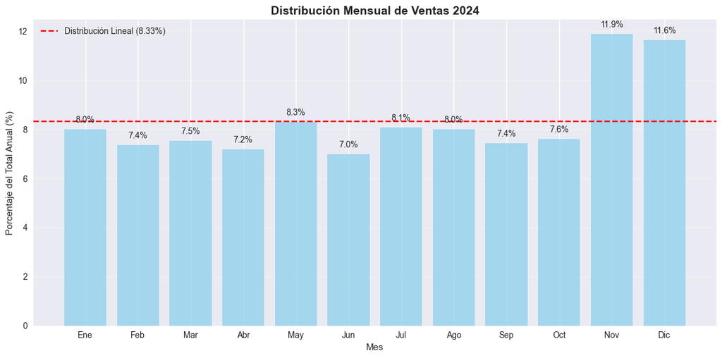

```
RESUMEN ESTACIONALIDAD:
- Ene-Sep representa el 68.9% del total anual
- Oct-Dic representa el 31.1% del total anual
- En distribución lineal: 75.0% vs 25.0%
```

```python
# Gráfico de distribución mensual
plt.figure(figsize=(12, 6))
meses_nombres = ['Ene', 'Feb', 'Mar', 'Abr', 'May', 'Jun',
                 'Jul', 'Ago', 'Sep', 'Oct', 'Nov', 'Dic']
porcentajes = [distribucion_mensual_2024[i] * 100 for i in range(1, 13)]

plt.bar(meses_nombres, porcentajes, color='skyblue', alpha=0.7)
plt.axhline(y=8.33, color='red', linestyle='--', label='Distribución Lineal (8.33%)')
plt.title('Distribución Mensual de Ventas 2024', fontsize=14, fontweight='bold')
plt.ylabel('Porcentaje del Total Anual (%)')
plt.xlabel('Mes')
plt.legend()
plt.grid(axis='y', alpha=0.3)

# Añadir valores en las barras
for i, v in enumerate(porcentajes):
    plt.text(i, v + 0.2, f'{v:.1f}%', ha='center', va='bottom')

plt.tight_layout()
plt.show()

print(f"\nRESUMEN ESTACIONALIDAD:")
print(f"- Ene-Sep representa el {sum(porcentajes[:9]):.1f}% del total anual")
print(f"- Oct-Dic representa el {sum(porcentajes[9:]):.1f}% del total anual")
print(f"- En distribución lineal: 75.0% vs 25.0%")
```

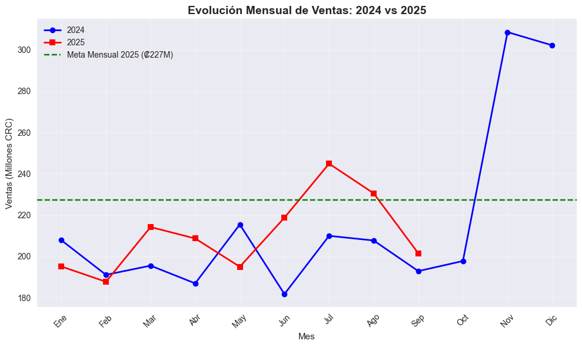

```python
# Gráfico comparativo
fig, ax1 = plt.subplots(figsize=(10, 6))

meta_mensual_2025 = meta_2025 / 12

# Gráfico 1: Evolución mensual comparativa
meses_2024 = ventas_mensuales[ventas_mensuales['Año'] == 2024]
meses_2025 = ventas_mensuales[ventas_mensuales['Año'] == 2025]

ax1.plot(meses_2024['Mes'], meses_2024['IngresoTotalCRC']/1e6,
         marker='o', linewidth=2, label='2024', color='blue')
ax1.plot(meses_2025['Mes'], meses_2025['IngresoTotalCRC']/1e6,
         marker='s', linewidth=2, label='2025', color='red')
ax1.axhline(y=meta_mensual_2025/1e6, color='green', linestyle='--',
           label=f'Meta Mensual 2025 (₡{meta_mensual_2025/1e6:.0f}M)')
ax1.set_title('Evolución Mensual de Ventas: 2024 vs 2025', fontsize=14, fontweight='bold')
ax1.set_xlabel('Mes')
ax1.set_ylabel('Ventas (Millones CRC)')
ax1.set_xticks(range(1,13))
ax1.set_xticklabels(['Ene','Feb','Mar','Abr','May','Jun','Jul','Ago','Sep','Oct','Nov','Dic'], rotation=45)
ax1.legend()
ax1.grid(True, alpha=0.3)

plt.tight_layout()
plt.show()

plt.tight_layout()
plt.show()
```

### 4.2. Análisis Comparativo 2024 vs 2025.

```python
print("4.2. Análisis Comparativo 2024 vs 2025.")
# Filtrar meses comparables (Enero a Septiembre)
df_comparable = df[df['Mes'] <= 9].copy()

# 1. ANÁLISIS POR CATEGORÍA DE PRODUCTO - CORREGIDO
print("\n1. ANÁLISIS POR CATEGORÍA")
categoria_analisis = df_comparable.groupby(['Año', 'CategoriaProducto']).agg({
    'IngresoTotalCRC': 'sum',
    'Margen': 'mean',  # Margen como promedio, no suma
    'CantidadVendida': 'sum'
}).reset_index()

# Pivot separado para ventas y margen
ventas_pivot = categoria_analisis.pivot_table(
    index='CategoriaProducto',
    columns='Año',
    values='IngresoTotalCRC',
    aggfunc='sum'
).fillna(0)

margen_pivot = categoria_analisis.pivot_table(
    index='CategoriaProducto',
    columns='Año',
    values='Margen',
    aggfunc='mean'
).fillna(0)

# Combinar resultados
categoria_resultado = pd.DataFrame({
    'IngresoTotalCRC_2024': ventas_pivot[2024],
    'IngresoTotalCRC_2025': ventas_pivot[2025],
    'Margen_2024': margen_pivot[2024],
    'Margen_2025': margen_pivot[2025]
})

# Calcular variaciones CORRECTAS
categoria_resultado['Variacion_Ventas'] = (
    (categoria_resultado['IngresoTotalCRC_2025'] - categoria_resultado['IngresoTotalCRC_2024']) /
    categoria_resultado['IngresoTotalCRC_2024'] * 100
)
categoria_resultado['Variacion_Margen'] = (
    (categoria_resultado['Margen_2025'] - categoria_resultado['Margen_2024']) * 100  # En puntos porcentuales
)

print(categoria_resultado[['IngresoTotalCRC_2024', 'IngresoTotalCRC_2025',
                          'Variacion_Ventas', 'Variacion_Margen']].round(2))

# 2. ANÁLISIS POR CANAL DE VENTA - MEJORADO
print("\n2. ANÁLISIS POR CANAL DE VENTA")
canal_analisis = df_comparable.groupby(['Año', 'CanalVenta']).agg({
    'IngresoTotalCRC': 'sum',
    'CantidadVendida': 'sum',
    'TiempoEntregaDias': 'mean'
}).reset_index()

canal_pivot = canal_analisis.pivot_table(
    index='CanalVenta',
    columns='Año',
    values='IngresoTotalCRC',
    aggfunc='sum'
).fillna(0)

# Renombrar columnas para claridad
canal_pivot = canal_pivot.rename(columns={2024: 'Ventas_2024', 2025: 'Ventas_2025'})

canal_pivot['Variacion'] = (
    (canal_pivot['Ventas_2025'] - canal_pivot['Ventas_2024']) / canal_pivot['Ventas_2024'] * 100
)
canal_pivot['Participacion_2025'] = (canal_pivot['Ventas_2025'] / canal_pivot['Ventas_2025'].sum()) * 100

print(canal_pivot.round(2))

# 3. ANÁLISIS POR PROVINCIA - MEJORADO
print("\n3. ANÁLISIS POR PROVINCIA")
provincia_analisis = df_comparable.groupby(['Año', 'Provincia']).agg({
    'IngresoTotalCRC': 'sum',
    'ClientesNuevos': 'sum'
}).reset_index()

provincia_pivot = provincia_analisis.pivot_table(
    index='Provincia',
    columns='Año',
    values='IngresoTotalCRC',
    aggfunc='sum'
).fillna(0)

# Renombrar columnas
provincia_pivot = provincia_pivot.rename(columns={2024: 'Ventas_2024', 2025: 'Ventas_2025'})

provincia_pivot['Variacion'] = (
    (provincia_pivot['Ventas_2025'] - provincia_pivot['Ventas_2024']) / provincia_pivot['Ventas_2024'] * 100
)
provincia_pivot['Participacion_2025'] = (provincia_pivot['Ventas_2025'] / provincia_pivot['Ventas_2025'].sum()) * 100

print(provincia_pivot.round(2))

# 4. ANÁLISIS POR TIPO DE CLIENTE - CORREGIDO
print("\n4. ANÁLISIS POR TIPO DE CLIENTE")
cliente_analisis = df_comparable.groupby(['Año', 'TipoCliente']).agg(
    IngresoTotalCRC_sum=('IngresoTotalCRC', 'sum'),
    CantidadVendida=('CantidadVendida', 'sum'),  # CORREGIDO: 'sum' en lugar de 'count'
    TicketPromedio=('IngresoTotalCRC', 'mean')
).reset_index()

# Pivot tables separados para claridad
ventas_cliente_pivot = cliente_analisis.pivot_table(
    index='TipoCliente',
    columns='Año',
    values='IngresoTotalCRC_sum',
    aggfunc='sum'
).fillna(0)

ticket_pivot = cliente_analisis.pivot_table(
    index='TipoCliente',
    columns='Año',
    values='TicketPromedio',
    aggfunc='mean'
).fillna(0)

# Combinar resultados
cliente_resultado = pd.DataFrame({
    'IngresoTotalCRC_2024': ventas_cliente_pivot[2024],
    'IngresoTotalCRC_2025': ventas_cliente_pivot[2025],
    'TicketPromedio_2024': ticket_pivot[2024],
    'TicketPromedio_2025': ticket_pivot[2025]
})

cliente_resultado['Variacion_Ventas'] = (
    (cliente_resultado['IngresoTotalCRC_2025'] - cliente_resultado['IngresoTotalCRC_2024']) /
    cliente_resultado['IngresoTotalCRC_2024'] * 100
)

print(cliente_resultado.round(2))
```

```
4.2. Análisis Comparativo 2024 vs 2025.

1. ANÁLISIS POR CATEGORÍA
                   IngresoTotalCRC_2024  IngresoTotalCRC_2025  \
CategoriaProducto
Electrodomésticos             491990057             522607627
Hogar                         143976371             150901626
Oficina                       254390904             287710419
Tecnología                    898692892             935040214

                   Variacion_Ventas  Variacion_Margen
CategoriaProducto
Electrodomésticos              6.22              0.20
Hogar                          4.81             -0.12
Oficina                       13.10             -0.13
Tecnología                     4.04             -0.08

2. ANÁLISIS POR CANAL DE VENTA
Año            Ventas_2024  Ventas_2025  Variacion  Participacion_2025
CanalVenta
E-commerce       492055755    510455042       3.74               26.92
Marketplace      263589400    275501253       4.52               14.53
Tienda Física    910939320    988200859       8.48               52.11
WhatsApp         122465749    122102732      -0.30                6.44

3. ANÁLISIS POR PROVINCIA
Año         Ventas_2024  Ventas_2025  Variacion  Participacion_2025
Provincia
Alajuela      340856046    385113336      12.98               20.31
Cartago       273503292    283506862       3.66               14.95
Guanacaste    129392670    128053542      -1.03                6.75
Heredia       283214520    286947407       1.32               15.13
Limón          54882196     54258887      -1.14                2.86
Puntarenas    164124506    170048930       3.61                8.97
San José      543076994    588330922       8.33               31.03

4. ANÁLISIS POR TIPO DE CLIENTE
               IngresoTotalCRC_2024  IngresoTotalCRC_2025  \
TipoCliente
Institucional             113562707             143567134
Mayorista                 249935653             233272029
Nuevo                     542801918             573933045
Recurrente                882749946             945487678

               TicketPromedio_2024  TicketPromedio_2025  Variacion_Ventas
TipoCliente
Institucional           283,906.77           330,039.39             26.42
Mayorista               307,802.53           300,996.17             -6.67
Nuevo                   294,840.80           309,231.17              5.74
Recurrente              284,482.74           301,398.69              7.11
```

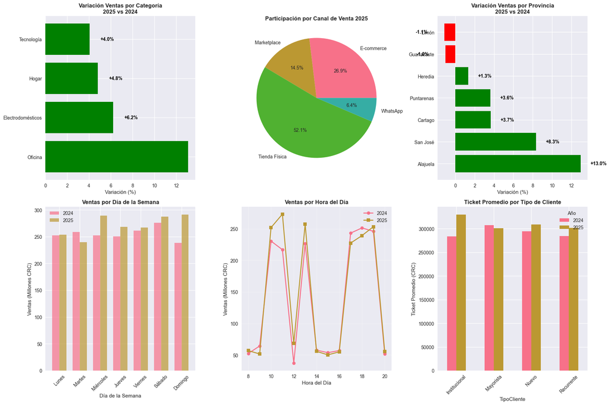

```python
# tendencias temporales para grafico
# Por día de la semana
dia_semana_analisis = df_comparable.groupby(['Año', 'DiaSemana']).agg({
    'IngresoTotalCRC': 'sum',
    'CantidadVendida': 'count'
}).reset_index()

# Por hora del día
hora_analisis = df_comparable.groupby(['Año', 'Hora']).agg({
    'IngresoTotalCRC': 'sum'
}).reset_index()

# Gráficos
fig, axes = plt.subplots(2, 3, figsize=(18, 12))

# Gráfico 1: Variación por categoría
categorias_orden = categoria_resultado['Variacion_Ventas'].sort_values(ascending=False).index
variaciones_cat = categoria_resultado.loc[categorias_orden, 'Variacion_Ventas']
colors = ['green' if x >= 0 else 'red' for x in variaciones_cat]
axes[0,0].barh(range(len(variaciones_cat)), variaciones_cat, color=colors)
axes[0,0].set_yticks(range(len(variaciones_cat)))
axes[0,0].set_yticklabels(categorias_orden)
axes[0,0].set_xlabel('Variación (%)')
axes[0,0].set_title('Variación Ventas por Categoría\n2025 vs 2024', fontweight='bold')
for i, v in enumerate(variaciones_cat):
    axes[0,0].text(v + (1 if v >= 0 else -5), i, f'{v:+.1f}%',
                   va='center', fontweight='bold', color='black' if abs(v) < 10 else 'white')

# Gráfico 2: Participación canales 2025
axes[0,1].pie(canal_pivot['Participacion_2025'], labels=canal_pivot.index, autopct='%1.1f%%')
axes[0,1].set_title('Participación por Canal de Venta 2025', fontweight='bold')

# Gráfico 3: Variación por provincia
provincia_orden = provincia_pivot['Variacion'].sort_values(ascending=False).index
variaciones_prov = provincia_pivot.loc[provincia_orden, 'Variacion']
colors_prov = ['green' if x >= 0 else 'red' for x in variaciones_prov]
axes[0,2].barh(range(len(variaciones_prov)), variaciones_prov, color=colors_prov)
axes[0,2].set_yticks(range(len(variaciones_prov)))
axes[0,2].set_yticklabels(provincia_orden)
axes[0,2].set_xlabel('Variación (%)')
axes[0,2].set_title('Variación Ventas por Provincia\n2025 vs 2024', fontweight='bold')
for i, v in enumerate(variaciones_prov):
    axes[0,2].text(v + (1 if v >= 0 else -3), i, f'{v:+.1f}%',
                   va='center', fontweight='bold', color='black' if abs(v) < 15 else 'white')

# Gráfico 4: Comportamiento por día de la semana
dias_orden = ['Lunes', 'Martes', 'Miércoles', 'Jueves', 'Viernes', 'Sábado', 'Domingo']
dia_semana_pivot = dia_semana_analisis.pivot_table(
    index='DiaSemana',
    columns='Año',
    values='IngresoTotalCRC',
    aggfunc='sum'
).reindex(dias_orden)

x = np.arange(len(dias_orden))
width = 0.35
axes[1,0].bar(x - width/2, dia_semana_pivot[2024]/1e6, width, label='2024', alpha=0.7)
axes[1,0].bar(x + width/2, dia_semana_pivot[2025]/1e6, width, label='2025', alpha=0.7)
axes[1,0].set_xlabel('Día de la Semana')
axes[1,0].set_ylabel('Ventas (Millones CRC)')
axes[1,0].set_title('Ventas por Día de la Semana', fontweight='bold')
axes[1,0].set_xticks(x)
axes[1,0].set_xticklabels(dias_orden, rotation=45)
axes[1,0].legend()

# Gráfico 5: Comportamiento por hora
hora_pivot = hora_analisis.pivot_table(
    index='Hora',
    columns='Año',
    values='IngresoTotalCRC',
    aggfunc='sum'
)
axes[1,1].plot(hora_pivot.index, hora_pivot[2024]/1e6, marker='o', label='2024', linewidth=2)
axes[1,1].plot(hora_pivot.index, hora_pivot[2025]/1e6, marker='s', label='2025', linewidth=2)
axes[1,1].set_xlabel('Hora del Día')
axes[1,1].set_ylabel('Ventas (Millones CRC)')
axes[1,1].set_title('Ventas por Hora del Día', fontweight='bold')
axes[1,1].legend()
axes[1,1].grid(True, alpha=0.3)

# Gráfico 6: Ticket promedio por tipo de cliente
ticket_pivot = cliente_analisis.pivot_table(
    index='TipoCliente',
    columns='Año',
    values='TicketPromedio',
    aggfunc='mean'
)
ticket_pivot.plot(kind='bar', ax=axes[1,2])
axes[1,2].set_title('Ticket Promedio por Tipo de Cliente', fontweight='bold')
axes[1,2].set_ylabel('Ticket Promedio (CRC)')
axes[1,2].ticklabel_format(style='plain', axis='y')
axes[1,2].legend(title='Año')
axes[1,2].tick_params(axis='x', rotation=45)

plt.tight_layout()
plt.show()
```

#### 4.2.2. Identificación de oportunidades y problemas.

```python
print("4.2.2. Identificación de Oportunidades y Problemas")
# Categorías con mejor y peor desempeño
mejor_categoria = categoria_resultado['Variacion_Ventas'].idxmax()
peor_categoria = categoria_resultado['Variacion_Ventas'].idxmin()
print(f"\n   MEJOR CATEGORÍA: {mejor_categoria} (+{categoria_resultado.loc[mejor_categoria, 'Variacion_Ventas']:.1f}%)")
print(f"   PEOR CATEGORÍA: {peor_categoria} ({categoria_resultado.loc[peor_categoria, 'Variacion_Ventas']:+.1f}%)")

# Provincias con mejor y peor desempeño
mejor_provincia = provincia_pivot['Variacion'].idxmax()
peor_provincia = provincia_pivot['Variacion'].idxmin()
print(f"   MEJOR PROVINCIA: {mejor_provincia} (+{provincia_pivot.loc[mejor_provincia, 'Variacion']:.1f}%)")
print(f"   PEOR PROVINCIA: {peor_provincia} ({provincia_pivot.loc[peor_provincia, 'Variacion']:+.1f}%)")

# Canal con mayor crecimiento
mejor_canal = canal_pivot['Variacion'].idxmax()
print(f"   CANAL CON MAYOR CRECIMIENTO: {mejor_canal} (+{canal_pivot.loc[mejor_canal, 'Variacion']:.1f}%)")
```

```
4.2.2. Identificación de Oportunidades y Problemas

   MEJOR CATEGORÍA: Oficina (+13.1%)
   PEOR CATEGORÍA: Tecnología (+4.0%)
   MEJOR PROVINCIA: Alajuela (+13.0%)
   PEOR PROVINCIA: Limón (-1.1%)
   CANAL CON MAYOR CRECIMIENTO: Tienda Física (+8.5%)
```

### 4.3. Análisis de temporadas Pasadas y estimación de Futuras.

```python
print("4.3. Análisis de temporadas Pasadas y estimación de Futuras.")
# 1. ANALIZAR COMPORTAMIENTO 2024 EN MESES OCT-DIC
temporadas_2024 = df[(df['Año'] == 2024) & (df['Mes'].isin([10, 11, 12]))].copy()

print("\n1. RESUMEN DE PICOS DE VENTAS 2024 (OCT-DIC):")
temporadas_mensual = temporadas_2024.groupby('Mes').agg({
    'IngresoTotalCRC': 'sum',
    'CantidadVendida': 'sum'
}).round(0)

# Método más robusto para campañas
def obtener_campana_principal(series):
    moda = series.mode()
    return moda.iloc[0] if not moda.empty else 'Normal'

campanas_mensuales = temporadas_2024.groupby('Mes')['Campaña'].apply(obtener_campana_principal)
temporadas_mensual['Campaña'] = campanas_mensuales
temporadas_mensual['Ventas_Millones'] = temporadas_mensual['IngresoTotalCRC'] / 1e6

print(temporadas_mensual[['Ventas_Millones', 'CantidadVendida', 'Campaña']])

# 2. ANÁLISIS POR CATEGORÍA EN TEMPORADAS
print("\n2. COMPORTAMIENTO POR CATEGORÍA EN TEMPORADAS 2024:")
temporadas_categoria = temporadas_2024.groupby('CategoriaProducto').agg({
    'IngresoTotalCRC': 'sum',
    'Margen': 'mean',
    'CantidadVendida': 'sum'
}).round(2)

print(temporadas_categoria)

# 3. PROYECCIÓN 2025 PARA MESES PENDIENTES - CORREGIDO
print("\n3. PROYECCIÓN 2025 PARA MESES PENDIENTES:")
ventas_oct_dic_2024 = temporadas_2024.groupby('Mes')['IngresoTotalCRC'].sum()

# USAR CRECIMIENTO REAL DEL 6% (no el 5% teórico)
tasa_crecimiento_real = 0.06  # Del análisis anterior
proyeccion_oct_dic_2025 = ventas_oct_dic_2024 * (1 + tasa_crecimiento_real)
proyeccion_total_oct_dic = proyeccion_oct_dic_2025.sum()

# Meta pendiente para alcanzar meta anual
ventas_2025_actual = df[df['Año'] == 2025]['IngresoTotalCRC'].sum()
meta_2025 = df[df['Año'] == 2024]['IngresoTotalCRC'].sum() * 1.05
meta_pendiente_oct_dic = meta_2025 - ventas_2025_actual

print(f"Proyección Octubre 2025: ₡{proyeccion_oct_dic_2025.get(10, 0):,.0f}")
print(f"Proyección Noviembre 2025: ₡{proyeccion_oct_dic_2025.get(11, 0):,.0f}")
print(f"Proyección Diciembre 2025: ₡{proyeccion_oct_dic_2025.get(12, 0):,.0f}")
print(f"TOTAL PROYECTADO OCT-DIC 2025: ₡{proyeccion_total_oct_dic:,.0f}")
print(f"Meta pendiente Oct-Dic: ₡{meta_pendiente_oct_dic:,.0f}")

# Análisis de capacidad de recuperación
diferencia_proyeccion = proyeccion_total_oct_dic - meta_pendiente_oct_dic
porcentaje_diferencia = (diferencia_proyeccion / meta_pendiente_oct_dic) * 100

print(f"\nCAPACIDAD DE RECUPERACIÓN:")
print(f"Diferencia: ₡{diferencia_proyeccion:,.0f} ({porcentaje_diferencia:+.1f}%)")

if diferencia_proyeccion >= 0:
    print("CONCLUSIÓN: La estacionalidad histórica indica CAPACIDAD DE RECUPERACIÓN de la brecha.")
else:
    print("CONCLUSIÓN: Se requiere esfuerzo adicional para alcanzar la meta anual.")

# 4. PRODUCTOS ESTRELLA EN TEMPORADAS
print("\n4. PRODUCTOS ESTRELLA EN TEMPORADAS 2024:")
productos_temporada = temporadas_2024.groupby(['CategoriaProducto', 'Producto']).agg({
    'IngresoTotalCRC': 'sum',
    'CantidadVendida': 'sum',
    'Margen': 'mean'
}).round(3)

# Top 10 productos por ingresos
top_productos_temporada = productos_temporada.nlargest(10, 'IngresoTotalCRC')
print(top_productos_temporada)

# 5. ANÁLISIS COMPARATIVO
print("\n5. IMPACTO DE TEMPORADA EN VENTAS ANUALES 2024:")
ventas_total_2024 = df[df['Año'] == 2024]['IngresoTotalCRC'].sum()
ventas_oct_dic_total = temporadas_2024['IngresoTotalCRC'].sum()
porcentaje_temporada = (ventas_oct_dic_total / ventas_total_2024) * 100

print(f"Ventas Oct-Dic 2024: ₡{ventas_oct_dic_total:,.0f}")
print(f"Ventas Total 2024: ₡{ventas_total_2024:,.0f}")
print(f"Participación Oct-Dic: {porcentaje_temporada:.1f}% del total anual")
```

```
4.3. Análisis de temporadas Pasadas y estimación de Futuras.

1. RESUMEN DE PICOS DE VENTAS 2024 (OCT-DIC):
     Ventas_Millones  CantidadVendida         Campaña
Mes
10            197.75             1552          Normal
11            308.53             2447       Mes Negro
12            302.15             2182  Temporada Alta

2. COMPORTAMIENTO POR CATEGORÍA EN TEMPORADAS 2024:
                   IngresoTotalCRC  Margen  CantidadVendida
CategoriaProducto
Electrodomésticos        233667858    0.23             1615
Hogar                     61163165    0.28             1484
Oficina                  119641239    0.23             1572
Tecnología               393961925    0.17             1510

3. PROYECCIÓN 2025 PARA MESES PENDIENTES:
Proyección Octubre 2025: ₡209,611,283
Proyección Noviembre 2025: ₡327,046,151
Proyección Diciembre 2025: ₡320,282,804
TOTAL PROYECTADO OCT-DIC 2025: ₡856,940,238
Meta pendiente Oct-Dic: ₡831,098,746

CAPACIDAD DE RECUPERACIÓN:
Diferencia: ₡25,841,493 (+3.1%)
CONCLUSIÓN: La estacionalidad histórica indica CAPACIDAD DE RECUPERACIÓN de la brecha.

4. PRODUCTOS ESTRELLA EN TEMPORADAS 2024:
                                 IngresoTotalCRC  CantidadVendida  Margen
CategoriaProducto Producto
Tecnología        Laptop                86267732              338    0.18
                  Smart TV              80195286              285    0.17
                  Tablet                78373483              293    0.17
                  Auriculares           76910852              311    0.17
                  Smartphone            72214572              283    0.17
Electrodomésticos Lavadora              56230739              384    0.23
                  Cafetera              52041645              357    0.22
                  Microondas            47307025              327    0.23
                  Ventilador            42323630              287    0.23
                  Refrigeradora         35764819              260    0.23

5. IMPACTO DE TEMPORADA EN VENTAS ANUALES 2024:
Ventas Oct-Dic 2024: ₡808,434,187
Ventas Total 2024: ₡2,597,484,411
Participación Oct-Dic: 31.1% del total anual
```

[figure not shown]

```python
# Gráficos de temporadas
fig, (ax1, ax2) = plt.subplots(1, 2, figsize=(15, 6))

# Gráfico 1: Comparativo mensual Oct-Dic
meses_nombres = {10: 'Octubre', 11: 'Noviembre', 12: 'Diciembre'}
ventas_2024_meses = [ventas_oct_dic_2024[10], ventas_oct_dic_2024[11], ventas_oct_dic_2024[12]]
ventas_2025_proy = [proyeccion_oct_dic_2025[10], proyeccion_oct_dic_2025[11], proyeccion_oct_dic_2025[12]]

x = np.arange(3)
width = 0.35
ax1.bar(x - width/2, [v/1e6 for v in ventas_2024_meses], width, label='2024 Real', alpha=0.7)
ax1.bar(x + width/2, [v/1e6 for v in ventas_2025_proy], width, label='2025 Proyectado', alpha=0.7)
ax1.set_xlabel('Mes')
ax1.set_ylabel('Ventas (Millones CRC)')
ax1.set_title('Comparativo Ventas Oct-Dic: 2024 vs Proyección 2025', fontweight='bold')
ax1.set_xticks(x)
ax1.set_xticklabels(['Octubre', 'Noviembre', 'Diciembre'])
ax1.legend()

for i, (v2024, v2025) in enumerate(zip(ventas_2024_meses, ventas_2025_proy)):
    crecimiento = ((v2025 - v2024) / v2024) * 100
    ax1.text(i, max(v2024, v2025)/1e6 + 5, f'+{crecimiento:.1f}%',
             ha='center', fontweight='bold')

# Gráfico 2: Productos estrella temporada
top_productos = productos_temporada.head(8)
ax2.barh(range(len(top_productos)), top_productos['IngresoTotalCRC']/1e6)
ax2.set_yticks(range(len(top_productos)))
ax2.set_yticklabels([f"{idx[1]}" for idx in top_productos.index])
ax2.set_xlabel('Ventas (Millones CRC)')
ax2.set_title('Top 8 Productos en Temporada Alta 2024', fontweight='bold')
for i, v in enumerate(top_productos['IngresoTotalCRC']/1e6):
    ax2.text(v + 0.1, i, f'{v:.1f}M', va='center', fontweight='bold')

plt.tight_layout()
plt.show()
```

### 4.4. Análisis de Fuerza de ventas.

```python
print("4.4. Análisis de Desempeño de Vendedores.")
# Filtrar meses comparables (Enero-Septiembre 2025)
df_vendedores_2025 = df_comparable[df_comparable['Año'] == 2025].copy()

print("\n1. RANKING COMPARATIVO DE VENDEDORES 2025 (Ene-Sep):")

# Análisis de vendedores 2025
vendedores_2025_analisis = df_vendedores_2025.groupby(['Vendedor', 'Provincia']).agg({
    'IngresoTotalCRC': 'sum',
    'CantidadVendida': 'sum',
    'Margen': 'mean',
    'ClientesNuevos': 'sum',
    'MetaVentas': 'first',    # Meta total de 21 meses
    'MetaMensual': 'first'    # Meta mensual (MetaVentas / 21)
}).reset_index()

# Meta acumulada = Meta mensual * 9 meses (Ene-Sep 2025)
vendedores_2025_analisis['MetaAcumulada_9meses'] = vendedores_2025_analisis['MetaMensual'] * 9
vendedores_2025_analisis['CumplimientoMeta_Acumulado'] = (
    vendedores_2025_analisis['IngresoTotalCRC'] / vendedores_2025_analisis['MetaAcumulada_9meses']
)

# Ranking 2025 por ventas
ranking_2025 = vendedores_2025_analisis.nlargest(18, 'IngresoTotalCRC')

print("ANALISIS POR VENDEDOR (Ene-Sep):")
print(ranking_2025[['Vendedor', 'Provincia', 'IngresoTotalCRC', 'CumplimientoMeta_Acumulado']].round(2))

# 2. CLASIFICACIÓN POR DESEMPEÑO 2025 - CORREGIDA
print("\n2. CLASIFICACIÓN POR DESEMPEÑO 2025 (Ene-Sep):")

# Segmentación basada en cumplimiento acumulado CORRECTO
condiciones = [
    vendedores_2025_analisis['CumplimientoMeta_Acumulado'] >= 1.2,
    vendedores_2025_analisis['CumplimientoMeta_Acumulado'] >= 0.8,
    vendedores_2025_analisis['CumplimientoMeta_Acumulado'] < 0.8
]
categorias = ['Sobresaliente', 'Estable', 'Bajo Desempeño']
vendedores_2025_analisis['Segmento'] = np.select(condiciones, categorias, default='Estable')

print("DISTRIBUCIÓN POR SEGMENTO:")
segmento_counts = vendedores_2025_analisis['Segmento'].value_counts()
print(segmento_counts)

# 3. ANÁLISIS POR UBICACIÓN GEOGRÁFICA - CORREGIDO
print("\n3. ANÁLISIS POR UBICACIÓN GEOGRÁFICA:")
vendedores_unicos_provincia = vendedores_2025_analisis.groupby('Provincia')['Vendedor'].nunique()

desempenio_provincia = vendedores_2025_analisis.groupby('Provincia').agg({
    'CumplimientoMeta_Acumulado': 'mean',
    'IngresoTotalCRC': 'sum',
    'Margen': 'mean',
    'ClientesNuevos': 'sum'
}).round(3)

desempenio_provincia['Vendedores_Unicos'] = vendedores_unicos_provincia
desempenio_provincia['VentasxVendedor'] = desempenio_provincia['IngresoTotalCRC'] / desempenio_provincia['Vendedores_Unicos']

print(desempenio_provincia)

# 4. ANÁLISIS DE BRECHAS INDIVIDUALES - CORREGIDO
print("\n4. BRECHAS INDIVIDUALES VS META ACUMULADA:")
vendedores_2025_analisis['BrechaAbsoluta'] = (
    vendedores_2025_analisis['MetaAcumulada_9meses'] - vendedores_2025_analisis['IngresoTotalCRC']
)
vendedores_2025_analisis['BrechaPorcentaje'] = (
    vendedores_2025_analisis['BrechaAbsoluta'] / vendedores_2025_analisis['MetaAcumulada_9meses'] * 100
)

# Identificar vendedores que necesitan apoyo
vendedores_con_brecha = vendedores_2025_analisis[vendedores_2025_analisis['CumplimientoMeta_Acumulado'] < 1.0]

if len(vendedores_con_brecha) > 0:
    print("MAYORES BRECHAS NEGATIVAS:")
    brechas_negativas = vendedores_con_brecha.nlargest(18, 'BrechaAbsoluta')[[
        'Vendedor', 'Provincia', 'CumplimientoMeta_Acumulado', 'BrechaAbsoluta', 'BrechaPorcentaje'
    ]]
    print(brechas_negativas.round(2))
else:
    print("Todos los vendedores cumplen o superan la meta acumulada")

# 5. VERIFICACIÓN DE CÁLCULOS
print("\n5. VERIFICACIÓN DE CÁLCULOS:")
print(f"Meta mensual promedio: ₡{vendedores_2025_analisis['MetaMensual'].mean():,.0f}")
print(f"Meta acumulada 9 meses promedio: ₡{vendedores_2025_analisis['MetaAcumulada_9meses'].mean():,.0f}")
print(f"Ventas promedio Ene-Sep: ₡{vendedores_2025_analisis['IngresoTotalCRC'].mean():,.0f}")
print(f"Cumplimiento promedio: {vendedores_2025_analisis['CumplimientoMeta_Acumulado'].mean():.1%}")
```

```
4.4. Análisis de Desempeño de Vendedores.

1. RANKING COMPARATIVO DE VENDEDORES 2025 (Ene-Sep):
ANALISIS POR VENDEDOR (Ene-Sep):
           Vendedor   Provincia  IngresoTotalCRC  CumplimientoMeta_Acumulado
11  Laura Rodríguez    San José        168247055                        1.01
2     Carlos Méndez    San José        149656174                        1.00
15      Pablo Solís     Cartago        144526098                        0.99
0        Ana Vargas    San José        141323624                        0.85
1   Andrea Martínez     Cartago        138980764                        0.95
17    Sofia Jiménez    Alajuela        135542337                        1.00
13  María Fernández    San José        129104069                        0.88
16  Roberto Navarro    Alajuela        126604792                        0.96
14      Miguel Soto    Alajuela        122966207                        0.88
4      David Chaves     Heredia        105316242                        0.92
6       Elena Rojas     Heredia         93055824                        1.01
8     Javier Campos     Heredia         88575341                        0.83
12     Luis Ramírez  Puntarenas         88002861                        0.95
3       Carmen Díaz  Puntarenas         82046069                        0.89
5     Diego Jiménez  Guanacaste         73067244                        1.10
7   Gabriela Torres  Guanacaste         54986298                        0.75
9        José Pérez       Limón         31002843                        0.89
10  Katherine Smith       Limón         23256044                        0.72

2. CLASIFICACIÓN POR DESEMPEÑO 2025 (Ene-Sep):
DISTRIBUCIÓN POR SEGMENTO:
Segmento
Estable           16
Bajo Desempeño     2
Name: count, dtype: int64

3. ANÁLISIS POR UBICACIÓN GEOGRÁFICA:
            CumplimientoMeta_Acumulado  IngresoTotalCRC  Margen  \
Provincia
Alajuela                          0.95        385113336    0.22
Cartago                           0.97        283506862    0.23
Guanacaste                        0.93        128053542    0.23
Heredia                           0.92        286947407    0.23
Limón                             0.81         54258887    0.22
Puntarenas                        0.92        170048930    0.23
```

[output cut: 34 more lines]

```
14             12.33
3              11.33
4               8.14
10             27.62
1               4.55
16              3.65
12              4.74
9              10.66
15              0.53

5. VERIFICACIÓN DE CÁLCULOS:
Meta mensual promedio: ₡12,535,487
Meta acumulada 9 meses promedio: ₡112,819,380
Ventas promedio Ene-Sep: ₡105,347,771
Cumplimiento promedio: 92.3%
```

### 4.5. Análisis Geográfico y de canales.

```python
print("4.5. Análisis Geográfico y de Potencial por Provincia.")
# Preparar datos para análisis geográfico (Enero-Septiembre)
df_geo = df_comparable.copy()

print("\n1. PROVINCIAS - CUMPLIMIENTO VS META")

# 1. Primero obtener las ventas reales por provincia
ventas_provincia_2025 = df_geo[df_geo['Año'] == 2025].groupby('Provincia').agg({
    'IngresoTotalCRC': 'sum',
    'ClientesNuevos': 'sum',
    'Vendedor': 'nunique',
    'Margen': 'mean'
}).reset_index()

# 2. Calcular metas provinciales (basadas en distribución histórica)
ventas_total_2024 = df_geo[df_geo['Año'] == 2024]['IngresoTotalCRC'].sum()
distribucion_provincial_2024 = df_geo[df_geo['Año'] == 2024].groupby('Provincia')['IngresoTotalCRC'].sum() / ventas_total_2024

# Meta 2025 total y proporcional para 9 meses
meta_total_2025 = ventas_total_2024 * 1.689 # Meta para nueve meses
meta_acumulada_2025 = meta_total_2025 * (9/12)  # Meta para 9 meses

# Asignar metas provinciales basadas en distribución 2024
ventas_provincia_2025['MetaProvincial_9meses'] = ventas_provincia_2025['Provincia'].map(
    distribucion_provincial_2024 * meta_acumulada_2025
)

# 3. Calcular cumplimiento CORRECTO
ventas_provincia_2025['CumplimientoMeta_Corregido'] = (
    ventas_provincia_2025['IngresoTotalCRC'] / ventas_provincia_2025['MetaProvincial_9meses']
)

print("CUMPLIMIENTO POR PROVINCIA 2025:")
for _, provincia in ventas_provincia_2025.iterrows():
    cumplimiento = provincia['CumplimientoMeta_Corregido']
    status = "SOBRE META" if cumplimiento >= 1.0 else "DEBAJO META"
    print(f"  {provincia['Provincia']}: {cumplimiento:.1%} - {status}")

# Análisis Comparativo 2024-2025 por Provincia
print("\n2. ANÁLISIS COMPARATIVO 2024-2025 POR PROVINCIA")

# Calcular crecimiento CORREGIDO
ventas_provincia_2024 = df_geo[df_geo['Año'] == 2024].groupby('Provincia').agg({
    'IngresoTotalCRC': 'sum',
    'ClientesNuevos': 'sum'
}).reset_index()

# Combinar datos 2024 y 2025
comparativo_provincias = pd.merge(
    ventas_provincia_2024.rename(columns={'IngresoTotalCRC': 'Ventas_2024', 'ClientesNuevos': 'Clientes_2024'}),
    ventas_provincia_2025.rename(columns={'IngresoTotalCRC': 'Ventas_2025', 'ClientesNuevos': 'Clientes_2025'}),
    on='Provincia'
)

# Calcular métricas de crecimiento
comparativo_provincias['Crecimiento_Ventas'] = (
    (comparativo_provincias['Ventas_2025'] - comparativo_provincias['Ventas_2024']) /
    comparativo_provincias['Ventas_2024'] * 100
)
comparativo_provincias['Crecimiento_Clientes'] = (
    (comparativo_provincias['Clientes_2025'] - comparativo_provincias['Clientes_2024']) /
    comparativo_provincias['Clientes_2024'] * 100
)
comparativo_provincias['Participacion_2025'] = (
    comparativo_provincias['Ventas_2025'] / comparativo_provincias['Ventas_2025'].sum() * 100
)

print("CRECIMIENTO Y PARTICIPACIÓN POR PROVINCIA:")
resultados_simplificados = comparativo_provincias[[
    'Provincia', 'Ventas_2024', 'Ventas_2025', 'Crecimiento_Ventas', 'Participacion_2025'
]].round(2)
print(resultados_simplificados.to_string(index=False))

# Identificación de Provincias con Potencial - SIMPLIFICADO
print("\n3. IDENTIFICACIÓN DE PROVINCIAS CON POTENCIAL")

# Métricas SIMPLES y SIGNIFICATIVAS
comparativo_provincias['Score_Simple'] = (
    comparativo_provincias['Crecimiento_Ventas'] * 0.5 +
    comparativo_provincias['Participacion_2025'] * 0.3 +
    comparativo_provincias['CumplimientoMeta_Corregido'] * 20 * 0.2
)

# Clasificación SIMPLE
conditions = [
    comparativo_provincias['Score_Simple'] >= 15,
    comparativo_provincias['Score_Simple'] >= 5,
    comparativo_provincias['Score_Simple'] < 5
]
choices = ['Alto Potencial', 'Potencial Medio', 'Bajo Potencial']
comparativo_provincias['Categoria_Potencial'] = np.select(conditions, choices, default='Potencial Medio')

print("CLASIFICACIÓN POR POTENCIAL DE CRECIMIENTO:")
for _, provincia in comparativo_provincias.iterrows():
    print(f"  {provincia['Provincia']}: {provincia['Categoria_Potencial']} " +
          f"(Score: {provincia['Score_Simple']:.1f}, Crecimiento: {provincia['Crecimiento_Ventas']:.1f}%)")

# Análisis de Canales por Provincia (esta parte estaba bien)
print("\n4. ANÁLISIS DE CANALES EFECTIVOS POR PROVINCIA")

canal_provincia = df_geo[df_geo['Año'] == 2025].groupby(['Provincia', 'CanalVenta']).agg({
    'IngresoTotalCRC': 'sum'
}).reset_index()

# Identificar canal principal por provincia
canal_principal = canal_provincia.loc[canal_provincia.groupby('Provincia')['IngresoTotalCRC'].idxmax()]

print("CANAL PRINCIPAL POR PROVINCIA 2025:")
for _, row in canal_principal.iterrows():
    provincia = row['Provincia']
    canal = row['CanalVenta']
    ventas = row['IngresoTotalCRC']
    total_provincia = comparativo_provincias[comparativo_provincias['Provincia'] == provincia]['Ventas_2025'].values[0]
    participacion = (ventas / total_provincia) * 100
    print(f"  {provincia}: {canal} ({participacion:.1f}% de ventas)")

print("\nRESUMEN - ANÁLISIS GEOGRÁFICO")
print(f"- Crecimiento promedio: {comparativo_provincias['Crecimiento_Ventas'].mean():.1f}%")
print(f"- Cumplimiento promedio: {comparativo_provincias['CumplimientoMeta_Corregido'].mean():.1%}")
print(f"- Provincias sobre meta: {(comparativo_provincias['CumplimientoMeta_Corregido'] >= 1.0).sum()} de {len(comparativo_provincias)}")
print(f"- Provincias alto potencial: {(comparativo_provincias['Categoria_Potencial'] == 'Alto Potencial').sum()}")
```

```
4.5. Análisis Geográfico y de Potencial por Provincia.

1. PROVINCIAS - CUMPLIMIENTO VS META
CUMPLIMIENTO POR PROVINCIA 2025:
  Alajuela: 89.2% - DEBAJO META
  Cartago: 81.8% - DEBAJO META
  Guanacaste: 78.1% - DEBAJO META
  Heredia: 80.0% - DEBAJO META
  Limón: 78.0% - DEBAJO META
  Puntarenas: 81.8% - DEBAJO META
  San José: 85.5% - DEBAJO META

2. ANÁLISIS COMPARATIVO 2024-2025 POR PROVINCIA
CRECIMIENTO Y PARTICIPACIÓN POR PROVINCIA:
 Provincia  Ventas_2024  Ventas_2025  Crecimiento_Ventas  Participacion_2025
  Alajuela    340856046    385113336               12.98               20.31
   Cartago    273503292    283506862                3.66               14.95
Guanacaste    129392670    128053542               -1.03                6.75
   Heredia    283214520    286947407                1.32               15.13
     Limón     54882196     54258887               -1.14                2.86
Puntarenas    164124506    170048930                3.61                8.97
  San José    543076994    588330922                8.33               31.03

3. IDENTIFICACIÓN DE PROVINCIAS CON POTENCIAL
CLASIFICACIÓN POR POTENCIAL DE CRECIMIENTO:
  Alajuela: Alto Potencial (Score: 16.2, Crecimiento: 13.0%)
  Cartago: Potencial Medio (Score: 9.6, Crecimiento: 3.7%)
  Guanacaste: Bajo Potencial (Score: 4.6, Crecimiento: -1.0%)
  Heredia: Potencial Medio (Score: 8.4, Crecimiento: 1.3%)
  Limón: Bajo Potencial (Score: 3.4, Crecimiento: -1.1%)
  Puntarenas: Potencial Medio (Score: 7.8, Crecimiento: 3.6%)
  San José: Alto Potencial (Score: 16.9, Crecimiento: 8.3%)

4. ANÁLISIS DE CANALES EFECTIVOS POR PROVINCIA
CANAL PRINCIPAL POR PROVINCIA 2025:
  Alajuela: Tienda Física (49.5% de ventas)
  Cartago: Tienda Física (52.4% de ventas)
  Guanacaste: Tienda Física (58.9% de ventas)
  Heredia: Tienda Física (52.3% de ventas)
  Limón: Tienda Física (59.9% de ventas)
  Puntarenas: Tienda Física (58.8% de ventas)
  San José: Tienda Física (49.5% de ventas)

RESUMEN - ANÁLISIS GEOGRÁFICO
- Crecimiento promedio: 4.0%
- Cumplimiento promedio: 82.1%
- Provincias sobre meta: 0 de 7
- Provincias alto potencial: 2
```

## 5. Análisis de margenes.

#### 5.1. Análisis de distribución de márgen y análisis de descuentos.

```python
# 1. Distribución de márgenes
print("5.1. DISTRIBUCIÓN MÁRGENES POR RANGO:")
margen_rangos = pd.cut(df['Margen'], bins=[-0.5, 0, 0.1, 0.15, 0.2, 0.25, 0.3, 0.5])
distribucion_margen = df.groupby(margen_rangos).agg({
    'IngresoTotalCRC': 'sum',
    'CantidadVendida': 'count'
})
print(distribucion_margen)

# 2. Margen por categoría
print("\nMARGEN POR CATEGORÍA:")
margen_categoria = df.groupby('CategoriaProducto').agg({
    'Margen': 'mean',
    'IngresoTotalCRC': 'sum',
    'CantidadVendida': 'count'
}).round(3)
print(margen_categoria)

# 3. Análisis descuentos (si existe la columna)
if 'DescuentoAplicado' in df.columns:
    print("\nIMPACTO DESCUENTOS EN MARGEN:")
    df['RangoDescuento'] = pd.cut(df['DescuentoAplicado'], bins=[0, 0.05, 0.1, 0.15, 0.2, 0.5])
    impacto_descuento = df.groupby('RangoDescuento')['Margen'].mean()
    print(impacto_descuento)
```

```
5.1. DISTRIBUCIÓN MÁRGENES POR RANGO:
             IngresoTotalCRC  CantidadVendida
Margen
(-0.5, 0.0]                0                0
(0.0, 0.1]         131269816              261
(0.1, 0.15]        500280184             1038
(0.15, 0.2]       1354663683             3114
(0.2, 0.25]       1637738828             5056
(0.25, 0.3]        752362068             3831
(0.3, 0.5]         117429718             1200

MARGEN POR CATEGORÍA:
                   Margen  IngresoTotalCRC  CantidadVendida
CategoriaProducto
Electrodomésticos    0.23       1248265542             3660
Hogar                0.28        356041162             3675
Oficina              0.23        661742562             3526
Tecnología           0.17       2227695031             3639

IMPACTO DESCUENTOS EN MARGEN:
RangoDescuento
(0.0, 0.05]   0.21
(0.05, 0.1]   0.18
(0.1, 0.15]   0.12
(0.15, 0.2]    NaN
(0.2, 0.5]     NaN
Name: Margen, dtype: float64
```

#### 5.2. Análisis por producto estrella.

```python
print("5.2. Análisis por productos.")

productos_rentabilidad = df.groupby(['CategoriaProducto', 'Producto']).agg({
    'IngresoTotalCRC': 'sum',
    'Margen': 'mean',
    'CantidadVendida': 'sum',
    'DescuentoAplicado': 'mean'
}).round(3)

# Productos más rentables vs más vendidos
productos_top_rentables = productos_rentabilidad.nlargest(10, 'Margen')
productos_top_ventas = productos_rentabilidad.nlargest(10, 'IngresoTotalCRC')

print("\nPRODUCTOS MÁS RENTABLES vs MÁS VENDIDOS:")
print("TOP 10 POR MARGEN:")
for idx, (producto, datos) in enumerate(productos_top_rentables.iterrows(), 1):
    print(f"{idx}. {producto[1]} ({producto[0]}): {datos['Margen']:.1%} margen - ₡{datos['IngresoTotalCRC']:,.0f} ventas")

print("\nTOP 10 POR VENTAS:")
for idx, (producto, datos) in enumerate(productos_top_ventas.iterrows(), 1):
    print(f"{idx}. {producto[1]} ({producto[0]}): ₡{datos['IngresoTotalCRC']:,.0f} - {datos['Margen']:.1%} margen")
```

```
5.2. Análisis por productos.

PRODUCTOS MÁS RENTABLES vs MÁS VENDIDOS:
TOP 10 POR MARGEN:
1. Juego de Sábanas (Hogar): 28.0% margen - ₡72,619,444 ventas
2. Organizador (Hogar): 27.9% margen - ₡72,718,104 ventas
3. Set de Cocina (Hogar): 27.9% margen - ₡66,911,280 ventas
4. Lámpara LED (Hogar): 27.8% margen - ₡69,880,204 ventas
5. Cortinas Modernas (Hogar): 27.7% margen - ₡73,912,130 ventas
6. Silla Ejecutiva (Oficina): 22.9% margen - ₡122,676,627 ventas
7. Microondas (Electrodomésticos): 22.7% margen - ₡270,122,127 ventas
8. Ventilador (Electrodomésticos): 22.7% margen - ₡222,570,650 ventas
9. Cafetera (Electrodomésticos): 22.6% margen - ₡254,545,056 ventas
10. Archivador (Oficina): 22.6% margen - ₡122,817,474 ventas

TOP 10 POR VENTAS:
1. Laptop (Tecnología): ₡463,348,860 - 17.8% margen
2. Smartphone (Tecnología): ₡463,238,910 - 17.2% margen
3. Smart TV (Tecnología): ₡448,344,801 - 17.2% margen
4. Tablet (Tecnología): ₡437,218,762 - 17.3% margen
5. Auriculares (Tecnología): ₡415,543,698 - 17.4% margen
6. Microondas (Electrodomésticos): ₡270,122,127 - 22.7% margen
7. Lavadora (Electrodomésticos): ₡258,008,824 - 22.4% margen
8. Cafetera (Electrodomésticos): ₡254,545,056 - 22.6% margen
9. Refrigeradora (Electrodomésticos): ₡243,018,885 - 22.5% margen
10. Ventilador (Electrodomésticos): ₡222,570,650 - 22.7% margen
```

#### 5.3. Análisis de margen por vendedor.

```python
print("5.3. Análisis por vendedores.")
# Eficiencia vs Rentabilidad por vendedor
vendedor_margen = df.groupby('Vendedor').agg({
    'IngresoTotalCRC': 'sum',
    'Margen': 'mean',
    'CantidadVendida': 'count',
    'DescuentoAplicado': 'mean'
}).round(3)

# Clasificar vendedores por eficiencia y rentabilidad
vendedor_margen['Eficiencia'] = vendedor_margen['IngresoTotalCRC'] / vendedor_margen['CantidadVendida']
vendedor_margen['Segmento'] = 'Medio'

# Top en rentabilidad
vendedor_margen.loc[vendedor_margen['Margen'] > vendedor_margen['Margen'].quantile(0.75), 'Segmento'] = 'Alta Rentabilidad'
vendedor_margen.loc[vendedor_margen['Margen'] < vendedor_margen['Margen'].quantile(0.25), 'Segmento'] = 'Baja Rentabilidad'

print("\nVENDEDORES POR SEGMENTO DE RENTABILIDAD:")
segmento_counts = vendedor_margen['Segmento'].value_counts()
for segmento, count in segmento_counts.items():
    avg_margin = vendedor_margen[vendedor_margen['Segmento'] == segmento]['Margen'].mean()
    print(f"    {segmento}: {count} vendedores ({avg_margin:.1%} margen promedio)")
```

```
5.3. Análisis por vendedores.

VENDEDORES POR SEGMENTO DE RENTABILIDAD:
    Medio: 9 vendedores (22.6% margen promedio)
    Alta Rentabilidad: 5 vendedores (22.9% margen promedio)
    Baja Rentabilidad: 4 vendedores (22.3% margen promedio)
```

#### 5.4. Análisis de margen por tipo de cliente.

```python
print("5.4. Análisis de marge por tipo de cliente.")
# Rentabilidad por perfil de cliente
cliente_rentabilidad = df.groupby('TipoCliente').agg({
    'IngresoTotalCRC': 'sum',
    'Margen': 'mean',
    'DescuentoAplicado': 'mean',
    'CantidadVendida': 'count'
}).round(3)

# Calcular valor lifetime por tipo de cliente
cliente_rentabilidad['ValorPorTransaccion'] = cliente_rentabilidad['IngresoTotalCRC'] / cliente_rentabilidad['CantidadVendida']
cliente_rentabilidad['ScoreRentabilidad'] = cliente_rentabilidad['Margen'] * cliente_rentabilidad['ValorPorTransaccion']

print("\nRENTABILIDAD POR TIPO DE CLIENTE:")
for tipo_cliente, datos in cliente_rentabilidad.iterrows():
    print(f"    {tipo_cliente}: {datos['Margen']:.1%} margen - ₡{datos['ValorPorTransaccion']:,.0f} por transacción")
```

```
5.4. Análisis de marge por tipo de cliente.

RENTABILIDAD POR TIPO DE CLIENTE:
    Institucional: 22.8% margen - ₡329,447 por transacción
    Mayorista: 22.7% margen - ₡312,715 por transacción
    Nuevo: 22.7% margen - ₡312,627 por transacción
    Recurrente: 22.6% margen - ₡304,961 por transacción
```

#### 5.5. Análisis estacionalidad de margenes.

```python
print("5.5. Análisis de evolución de márgenes y descuentos.")
# Evolución de márgenes por mes
margen_mensual = df.groupby(['Año', 'Mes']).agg({
    'Margen': 'mean',
    'IngresoTotalCRC': 'sum',
    'DescuentoAplicado': 'mean'
}).reset_index()

# Comparar 2024 vs 2025
margen_mensual_pivot = margen_mensual.pivot_table(
    index='Mes',
    columns='Año',
    values=['Margen', 'DescuentoAplicado']
).round(3)

print("\nEVOLUCIÓN MARGENES MENSUALES 2024 vs 2025:")
print(margen_mensual_pivot[['Margen', 'DescuentoAplicado']])
```

```
5.5. Análisis de evolución de márgenes y descuentos.

EVOLUCIÓN MARGENES MENSUALES 2024 vs 2025:
    Margen      DescuentoAplicado
Año   2024 2025              2024 2025
Mes
1     0.23 0.23              0.03 0.03
2     0.22 0.23              0.03 0.03
3     0.22 0.23              0.03 0.03
4     0.23 0.23              0.03 0.03
5     0.23 0.23              0.03 0.03
6     0.23 0.22              0.03 0.03
7     0.23 0.23              0.03 0.03
8     0.23 0.22              0.03 0.03
9     0.23 0.23              0.03 0.03
10    0.23  NaN              0.03  NaN
11    0.23  NaN              0.03  NaN
12    0.23  NaN              0.03  NaN
```

#### 5.6. Análisis Margen por canal y categoría.

```python
print("5.6. Identificación de oportunidades específicos.")
# Cruce canal-categoría para identificar combinaciones rentables
margen_canal_categoria = df.groupby(['CanalVenta', 'CategoriaProducto']).agg({
    'Margen': 'mean',
    'IngresoTotalCRC': 'sum',
    'CantidadVendida': 'count'
}).round(3)

# Encontrar oportunidades y problemas específicos
print("\nMARGEN POR CANAL Y CATEGORÍA:")
for (canal, categoria), datos in margen_canal_categoria.iterrows():
    if datos['Margen'] > 0.25:
        print(f"    OPORTUNIDAD: {canal} + {categoria} = {datos['Margen']:.1%} margen")
    elif datos['Margen'] < 0.15:
        print(f"    PROBLEMA: {canal} + {categoria} = {datos['Margen']:.1%} margen")
```

```
5.6. Identificación de oportunidades específicos.

MARGEN POR CANAL Y CATEGORÍA:
    OPORTUNIDAD: E-commerce + Hogar = 27.8% margen
    OPORTUNIDAD: Marketplace + Hogar = 27.9% margen
    OPORTUNIDAD: Tienda Física + Hogar = 27.9% margen
    OPORTUNIDAD: WhatsApp + Hogar = 28.1% margen
```

#### 5.7. Análisis de transacciones de BAJO margen.

```python
print("5.7. Análisis de transacciones de BAJO margen.")
# Investigar específicamente las transacciones con margen <10%
transacciones_bajo_margen = df[df['Margen'] < 0.10]

if len(transacciones_bajo_margen) > 0:
    analisis_bajo_margen = transacciones_bajo_margen.groupby('CategoriaProducto').agg({
        'IngresoTotalCRC': 'sum',
        'Margen': 'mean',
        'DescuentoAplicado': 'mean',
        'CantidadVendida': 'count'
    }).round(3)

    print("\nINVESTIGACIÓN TRANSACCIONES MARGEN <10%:")
    print(f"Total afectado: ₡{transacciones_bajo_margen['IngresoTotalCRC'].sum():,.0f}")
    for categoria, datos in analisis_bajo_margen.iterrows():
        print(f"    {categoria}: {datos['CantidadVendida']} transacciones, descuento promedio {datos['DescuentoAplicado']:.1%}")
```

```
5.7. Análisis de transacciones de BAJO margen.

INVESTIGACIÓN TRANSACCIONES MARGEN <10%:
Total afectado: ₡127,337,127
    Electrodomésticos: 25.0 transacciones, descuento promedio 15.0%
    Oficina: 22.0 transacciones, descuento promedio 15.0%
    Tecnología: 201.0 transacciones, descuento promedio 10.9%
```

#### 5.8. Análisis comparativo de impacto.

```python
print("5.8. Cálculo de impacto potencial de mejorar márgenes.")
# Calcular impacto potencial de mejorar márgenes
impacto_potencial = {}

# Escenario 1: Eliminar transacciones <10% margen
ventas_bajo_margen = transacciones_bajo_margen['IngresoTotalCRC'].sum()
margen_promedio_bajo = transacciones_bajo_margen['Margen'].mean()
impacto_eliminar_bajos = ventas_bajo_margen * (0.20 - margen_promedio_bajo)  # Asumiendo 20% margen objetivo

# Escenario 2: Mejorar margen Tecnología al promedio
ventas_tecnologia = df[df['CategoriaProducto'] == 'Tecnología']['IngresoTotalCRC'].sum()
margen_actual_tech = df[df['CategoriaProducto'] == 'Tecnología']['Margen'].mean()
margen_promedio_general = df['Margen'].mean()
impacto_mejorar_tech = ventas_tecnologia * (margen_promedio_general - margen_actual_tech)

print(f"\nIMPACTO POTENCIAL ESTRATEGIAS MARGEN:")
print(f"- Eliminar ventas <10% margen: ₡{impacto_eliminar_bajos:,.0f}")
print(f"- Mejorar Tecnología al promedio: ₡{impacto_mejorar_tech:,.0f}")
print(f"- Total oportunidad: ₡{impacto_eliminar_bajos + impacto_mejorar_tech:,.0f}")
```

```
5.8. Cálculo de impacto potencial de mejorar márgenes.

IMPACTO POTENCIAL ESTRATEGIAS MARGEN:
- Eliminar ventas <10% margen: ₡15,856,553
- Mejorar Tecnología al promedio: ₡116,468,028
- Total oportunidad: ₡132,324,581
```

## 6. Análisis Estadístico avanzado y validación.

### 6.1. Tests de significancia estadística.

```python
print("6.1. Pruebas de significancia estadística.")
# # Test de significancia en variaciones interanuales
print("\n1. SIGNIFICANCIA ESTADÍSTICA EN VARIACIONES 2024-2025")

# Preparar datos para tests
ventas_diarias_2024 = df[df['Año'] == 2024].groupby('Fecha')['IngresoTotalCRC'].sum()
ventas_diarias_2025 = df[df['Año'] == 2025].groupby('Fecha')['IngresoTotalCRC'].sum()

# Test T para diferencia de medias
t_stat, p_value = ttest_ind(ventas_diarias_2024, ventas_diarias_2025, equal_var=False)
print(f"- Test T ventas diarias: t={t_stat:.3f}, p-value={p_value:.4f}")
print(f"  → La diferencia {'ES' if p_value < 0.05 else 'NO ES'} estadísticamente significativa")

# Test por categoría
print("\n2. SIGNIFICANCIA POR CATEGORÍA DE PRODUCTO:")
for categoria in df['CategoriaProducto'].unique():
    ventas_cat_2024 = df[(df['Año'] == 2024) & (df['CategoriaProducto'] == categoria)]['IngresoTotalCRC']
    ventas_cat_2025 = df[(df['Año'] == 2025) & (df['CategoriaProducto'] == categoria)]['IngresoTotalCRC']

    if len(ventas_cat_2024) > 30 and len(ventas_cat_2025) > 30:  # Mínimo para test
        t_stat, p_value = ttest_ind(ventas_cat_2024, ventas_cat_2025, equal_var=False)
        significancia = "✓" if p_value < 0.05 else "✗"
        print(f"  {significancia} {categoria}: p-value={p_value:.4f}")

# Test de chi-cuadrado para proporciones de canal
print("\n3. TEST DE INDEPENDENCIA - CANALES DE VENTA:")
contingency_table = pd.crosstab(df[df['Año'] == 2025]['Provincia'],
                               df[df['Año'] == 2025]['CanalVenta'])
chi2, p_value, dof, expected = chi2_contingency(contingency_table)
print(f"- Test Chi-cuadrado canales vs provincia: χ²={chi2:.3f}, p-value={p_value:.4f}")
print(f"  → La distribución de canales {'VARÍA' if p_value < 0.05 else 'NO VARÍA'} significativamente por provincia")
```

[output not shown]

### 6.2. Análisis de correlaciones Multivariado.

```python
print("6.2. Análisis de correlaciones entre variables clave.")
# Seleccionar variables numéricas para correlación
variables_correlacion = [
    'IngresoTotalCRC', 'Margen', 'CantidadVendida', 'TiempoEntregaDias',
    'SatisfacciónCliente', 'DescuentoAplicado', 'ClientesNuevos'
]
df_correlacion = df[variables_correlacion].corr(method='pearson')

# Test de significancia para cada correlación
print("\nCORRELACIONES SIGNIFICATIVAS (p < 0.05):")
for i, var1 in enumerate(variables_correlacion):
    for j, var2 in enumerate(variables_correlacion):
        if i < j:  # Evitar duplicados
            corr, p_value = pearsonr(df[var1].dropna(), df[var2].dropna())
            if abs(corr) > 0.3 and p_value < 0.05:
                direccion = "positiva" if corr > 0 else "negativa"
                print(f"    {var1} - {var2}: r={corr:.3f} ({direccion})")

# Correlación específica: TiempoEntrega vs Satisfacción
corr_entrega_satisf, p_entrega_satisf = pearsonr(
    df['TiempoEntregaDias'].dropna(),
    df['SatisfacciónCliente'].dropna()
)
print(f"    Correlación Tiempo Entrega vs Satisfacción: r={corr_entrega_satisf:.3f}, p={p_entrega_satisf:.4f}")
```

```
6.2. Análisis de correlaciones entre variables clave.

CORRELACIONES SIGNIFICATIVAS (p < 0.05):
    IngresoTotalCRC - Margen: r=-0.321 (negativa)
    IngresoTotalCRC - CantidadVendida: r=0.581 (positiva)
    Margen - DescuentoAplicado: r=-0.532 (negativa)
    TiempoEntregaDias - SatisfacciónCliente: r=-0.801 (negativa)
    SatisfacciónCliente - ClientesNuevos: r=-0.336 (negativa)
    Correlación Tiempo Entrega vs Satisfacción: r=-0.801, p=0.0000
```

### 6.3. Validación de supuestos de proyecciones.

```python
print("6.3. Análisis de tendencias y estacionalidad.")
# Calcular crecimiento mensual
crecimiento_mensual = ventas_mensuales.groupby('Mes')['IngresoTotalCRC'].pct_change().dropna()
stat, p_value = shapiro(crecimiento_mensual)
print(f"\n Test de normalidad (Shapiro-Wilk) en crecimiento: p-value={p_value:.4f}")
print(f"    Los datos de crecimiento {'SON' if p_value > 0.05 else 'NO SON'} normales")

# Análisis de estacionalidad con descomposición
from statsmodels.tsa.seasonal import seasonal_decompose

# Preparar serie temporal mensual
serie_mensual = ventas_mensuales.set_index('Mes')['IngresoTotalCRC']
if len(serie_mensual) >= 24:  # Mínimo para descomposición
    decomposition = seasonal_decompose(serie_mensual, model='additive', period=12)
    estacionalidad = decomposition.seasonal.std()
    print(f"Fuerza de estacionalidad: σ={estacionalidad:,.0f}")
```

```
6.3. Análisis de tendencias y estacionalidad.

 Test de normalidad (Shapiro-Wilk) en crecimiento: p-value=0.7034
    Los datos de crecimiento SON normales
```

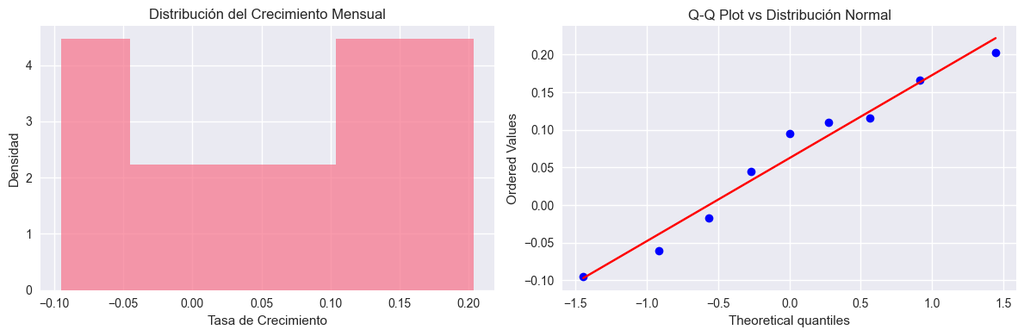

```python
import matplotlib.pyplot as plt

fig, (ax1, ax2) = plt.subplots(1, 2, figsize=(12, 4))

# Histograma + distribución normal
ax1.hist(crecimiento_mensual, bins=6, density=True, alpha=0.7)
ax1.set_title('Distribución del Crecimiento Mensual')
ax1.set_xlabel('Tasa de Crecimiento')
ax1.set_ylabel('Densidad')

# QQ-Plot
from scipy.stats import probplot
probplot(crecimiento_mensual, dist="norm", plot=ax2)
ax2.set_title('Q-Q Plot vs Distribución Normal')

plt.tight_layout()
plt.show()
```

```python
print("Estimación de Kurosis")
from scipy.stats import skew, kurtosis
skewness = skew(crecimiento_mensual)
kurt = kurtosis(crecimiento_mensual)
print(f"\nSesgo: {skewness:.3f} (=0 para normal)")
print(f"Curtosis: {kurt:.3f} (=0 para normal)")

# Regla práctica: si |skewness| < 2 y |kurtosis| < 4, "suficientemente normal"
es_aceptable = abs(skewness) < 2 and abs(kurt) < 4
print(f"Distribución aceptable para análisis: {es_aceptable}")
```

```
Estimación de Kurosis

Sesgo: -0.260 (=0 para normal)
Curtosis: -1.182 (=0 para normal)
Distribución aceptable para análisis: True
```

```python
# Para análisis de sensibilidad sin asumir normalidad
def bootstrap_confidence_interval(data, n_bootstrap=1000):
    bootstrapped_means = []
    for _ in range(n_bootstrap):
        sample = np.random.choice(data, size=len(data), replace=True)
        bootstrapped_means.append(np.mean(sample))

    ci_lower = np.percentile(bootstrapped_means, 2.5)
    ci_upper = np.percentile(bootstrapped_means, 97.5)
    return ci_lower, ci_upper

ci_lower, ci_upper = bootstrap_confidence_interval(crecimiento_mensual)
print(f"IC 95% bootstrap: [{ci_lower:.3f}, {ci_upper:.3f}]")
```

```
IC 95% bootstrap: [0.001, 0.125]
```

### 6.4. Análisis de sensibilidad.

#### 6.4.1. Escenarios altenativos: Calcula múltiples escenarios con diferentes supuestos.

```python
print("6.4.1, Escenarios de proyección bajo incertidumbre.")
def calcular_escenarios(ventas_base, factores_incertidumbre):
    escenarios = {
        'Optimista': {
            'crecimiento_extra': 1.15,
            'efectividad_acciones': 1.25,
            'tasa_clientes_nuevos': 1.20
        },
        'Base': {
            'crecimiento_extra': 1.05,
            'efectividad_acciones': 1.00,
            'tasa_clientes_nuevos': 1.00
        },
        'Pesimista': {
            'crecimiento_extra': 0.95,
            'efectividad_acciones': 0.75,
            'tasa_clientes_nuevos': 0.80
        },
        'Recesión': {
            'crecimiento_extra': 0.85,
            'efectividad_acciones': 0.60,
            'tasa_clientes_nuevos': 0.70
        }
    }

    resultados = {}
    for nombre, factores in escenarios.items():
        proyeccion = (ventas_base *
                     factores['crecimiento_extra'] *
                     factores['efectividad_acciones'] *
                     factores['tasa_clientes_nuevos'])
        resultados[nombre] = proyeccion

    return resultados

# Aplicar escenarios a proyección
proyeccion_base = proyeccion_total_2025
escenarios_proyeccion = calcular_escenarios(proyeccion_base, {})

print("\n1. ESCENARIOS DE PROYECCIÓN 2025:")
for escenario, valor in escenarios_proyeccion.items():
    brecha_escenario = valor - meta_2025
    cumplimiento_escenario = valor / meta_2025
    print(f"  - {escenario}: ₡{valor:,.0f} ({cumplimiento_escenario:.1%}) = Brecha: ₡{brecha_escenario:,.0f}")
```

```
6.4.1, Escenarios de proyección bajo incertidumbre.

1. ESCENARIOS DE PROYECCIÓN 2025:
  - Optimista: ₡4,749,166,268 (174.1%) = Brecha: ₡2,021,807,636
  - Base: ₡2,890,796,859 (106.0%) = Brecha: ₡163,438,227
  - Pesimista: ₡1,569,289,723 (57.5%) = Brecha: ₡-1,158,068,908
  - Recesión: ₡982,870,932 (36.0%) = Brecha: ₡-1,744,487,700
```

#### 6.4.2. Análisis What - IF.

```python
print("6.4.2. Simulación de impacto de acciones estratégicas.")
def simular_impacto_acciones(acciones, ventas_base):
    impactos = {
        'incremento_marketing_digital': 1.08,      # +8%
        'mejora_tiempo_entrega': 1.05,             # +5%
        'programa_fidelizacion': 1.12,             # +12%
        'capacitacion_vendedores': 1.10,           # +10%
        'optimizacion_precios': 1.06,              # +6%
        'expansion_provincias': 1.15               # +15%
    }

    # Combinar acciones seleccionadas
    factor_total = 1.0
    for accion in acciones:
        factor_total *= impactos.get(accion, 1.0)

    return ventas_base * factor_total

# Simular combinaciones de acciones
combinaciones_acciones = [
    ['incremento_marketing_digital', 'capacitacion_vendedores'],
    ['programa_fidelizacion', 'mejora_tiempo_entrega'],
    ['expansion_provincias', 'optimizacion_precios', 'capacitacion_vendedores']
]

print("\nIMPACTO DE COMBINACIONES DE ACCIONES:")
for i, combinacion in enumerate(combinaciones_acciones, 1):
    ventas_simuladas = simular_impacto_acciones(combinacion, proyeccion_base)
    impacto = ((ventas_simuladas - proyeccion_base) / proyeccion_base) * 100
    print(f"   Opción {i} ({', '.join(combinacion)}): +{impacto:.1f}% → ₡{ventas_simuladas:,.0f}")
```

```
6.4.2. Simulación de impacto de acciones estratégicas.

IMPACTO DE COMBINACIONES DE ACCIONES:
   Opción 1 (incremento_marketing_digital, capacitacion_vendedores): +18.8% → ₡3,270,730,160
   Opción 2 (programa_fidelizacion, mejora_tiempo_entrega): +17.6% → ₡3,237,692,482
   Opción 3 (expansion_provincias, optimizacion_precios, capacitacion_vendedores): +34.1% → ₡3,691,685,246
```

#### 6.4.3. Impacto de Factores Externos.

```python
print("6.4.3. Evaluación del impacto de factores macroeconómicos.")
factores_externos = {
    'Crecimiento PIB Costa Rica': {
        'optimista': 1.04,    # +4%
        'base': 1.02,         # +2%
        'pesimista': 0.98     # -2%
    },
    'Tipo de cambio USD/CRC': {
        'optimista': 0.95,    # Apreciación 5%
        'base': 1.00,         # Estable
        'pesimista': 1.08     # Depreciación 8%
    },
    'Inflación': {
        'optimista': 0.96,    # Baja inflación
        'base': 1.00,         # Inflación esperada
        'pesimista': 1.06     # Alta inflación
    }
}

# Simular impacto combinado de factores externos
print("\nIMPACTO FACTORES MACROECONÓMICOS:")
for escenario in ['optimista', 'base', 'pesimista']:
    factor_combinado = 1.0
    for factor, valores in factores_externos.items():
        factor_combinado *= valores[escenario]

    ventas_ajustadas = proyeccion_base * factor_combinado
    impacto_externo = (factor_combinado - 1) * 100

    print(f"   {escenario.capitalize()}: {impacto_externo:+.1f}% → ₡{ventas_ajustadas:,.0f}")
```

```
6.4.3. Evaluación del impacto de factores macroeconómicos.

IMPACTO FACTORES MACROECONÓMICOS:
   Optimista: -5.2% → ₡2,611,298,100
   Base: +2.0% → ₡2,808,202,663
   Pesimista: +12.2% → ₡3,088,758,628
```

#### 6.4.4. Análisis de sensibilidad paramétrico

```python
print("6.4.4. Análisis de sensibilidad a variaciones clave.")
# Sensibilidad a variaciones en crecimiento
variaciones_crecimiento = np.arange(-0.10, 0.11, 0.02)  # -10% to +10%

print("\nSENSIBILIDAD A VARIACIONES EN TASA DE CRECIMIENTO:")
for variacion in variaciones_crecimiento:
    if variacion != 0:
        proyeccion_sensibilidad = proyeccion_base * (1 + variacion)
        brecha_sensibilidad = proyeccion_sensibilidad - meta_2025
        print(f"     {variacion:+.0%}: ₡{proyeccion_sensibilidad:,.0f} = (Brecha: ₡{brecha_sensibilidad:,.0f})")
```

```
6.4.4. Análisis de sensibilidad a variaciones clave.

SENSIBILIDAD A VARIACIONES EN TASA DE CRECIMIENTO:
     -10%: ₡2,477,825,879 = (Brecha: ₡-249,532,753)
     -8%: ₡2,532,888,676 = (Brecha: ₡-194,469,955)
     -6%: ₡2,587,951,474 = (Brecha: ₡-139,407,158)
     -4%: ₡2,643,014,271 = (Brecha: ₡-84,344,361)
     -2%: ₡2,698,077,068 = (Brecha: ₡-29,281,563)
     +0%: ₡2,753,139,866 = (Brecha: ₡25,781,234)
     +2%: ₡2,808,202,663 = (Brecha: ₡80,844,031)
     +4%: ₡2,863,265,460 = (Brecha: ₡135,906,829)
     +6%: ₡2,918,328,257 = (Brecha: ₡190,969,626)
     +8%: ₡2,973,391,055 = (Brecha: ₡246,032,423)
     +10%: ₡3,028,453,852 = (Brecha: ₡301,095,221)
```

### 6.5. Benchmarking y Análisis competitivo.

#### 6.5.1. Benchmarking con estándares de Industria.

```python
print("6.5.1. Benchmarking con estandares de Industria")
benchmarks_empresa_mediana = {
    'margen_bruto_promedio': 0.26,
    'crecimiento_anual_promedio': 0.06,
    'ticket_promedio': 350000,
    'ratio_ventas_vendedor': 120000000,
}

margen_actual = df['Margen'].mean()
benchmark_margen = benchmarks_empresa_mediana['margen_bruto_promedio']
diff_margen = margen_actual - benchmark_margen
estado_margen = " SOBRE" if diff_margen > 0 else "  BAJO"
print(f"\n1. ANÁLISIS DE RENTABILIDAD:")
print(f"   - Margen bruto actual: {margen_actual:.1%}")
print(f"   - Benchmark Empresas Medianas CR: {benchmark_margen:.1%}")
print(f"   - Diferencia: {diff_margen:+.1%} {estado_margen} estándar")

# 2. CRECIMIENTO COMPARABLE
ventas_ene_sep_2024 = df[(df['Año'] == 2024) & (df['Mes'] <= 9)]['IngresoTotalCRC'].sum()
crecimiento_comparable = (ventas_2025_actual / ventas_ene_sep_2024) - 1
benchmark_crecimiento = benchmarks_empresa_mediana['crecimiento_anual_promedio']
diff_crecimiento = crecimiento_comparable - benchmark_crecimiento
estado_crecimiento = " SOBRE" if diff_crecimiento > 0 else "  BAJO"
print(f"\n2. ANÁLISIS DE CRECIMIENTO:")
print(f"   - Crecimiento comparable: {crecimiento_comparable:.1%}")
print(f"   - Benchmark sector: {benchmark_crecimiento:.1%}")
print(f"   - Diferencia: {diff_crecimiento:+.1%} {estado_crecimiento} sector")

# 3. EFICIENCIA COMERCIAL
ventas_vendedor_9meses = df[df['Año'] == 2025].groupby('Vendedor')['IngresoTotalCRC'].sum().mean()
ventas_vendedor_anual = ventas_vendedor_9meses * 12/9
benchmark_vendedor = benchmarks_empresa_mediana['ratio_ventas_vendedor']
diff_vendedor = ventas_vendedor_anual - benchmark_vendedor
estado_vendedor = " SOBRE" if diff_vendedor > 0 else "  BAJO"
print(f"\n3. ANÁLISIS DE EFICIENCIA COMERCIAL:")
print(f"   - Ventas por vendedor (anualizado): ₡{ventas_vendedor_anual:,.0f}")
print(f"   - Benchmark: ₡{benchmark_vendedor:,.0f}")
print(f"   - Diferencia: {diff_vendedor/benchmark_vendedor:+.1%} {estado_vendedor} estándar")

# 4. TICKET PROMEDIO
ticket_actual = df[df['Año'] == 2025]['IngresoTotalCRC'].mean()
benchmark_ticket = benchmarks_empresa_mediana['ticket_promedio']
diff_ticket = ticket_actual - benchmark_ticket
estado_ticket = " SOBRE" if diff_ticket > 0 else "  BAJO"
print(f"\n4. ANÁLISIS DE TICKET PROMEDIO:")
print(f"   - Ticket promedio actual: ₡{ticket_actual:,.0f}")
print(f"   - Benchmark: ₡{benchmark_ticket:,.0f}")
print(f"   - Diferencia: {diff_ticket/benchmark_ticket:+.1%} {estado_ticket} estándar")
```

```
6.5.1. Benchmarking con estandares de Industria

1. ANÁLISIS DE RENTABILIDAD:
   - Margen bruto actual: 22.6%
   - Benchmark Empresas Medianas CR: 26.0%
   - Diferencia: -3.4%   BAJO estándar

2. ANÁLISIS DE CRECIMIENTO:
   - Crecimiento comparable: 6.0%
   - Benchmark sector: 6.0%
   - Diferencia: -0.0%   BAJO sector

3. ANÁLISIS DE EFICIENCIA COMERCIAL:
   - Ventas por vendedor (anualizado): ₡140,463,695
   - Benchmark: ₡120,000,000
   - Diferencia: +17.1%  SOBRE estándar

4. ANÁLISIS DE TICKET PROMEDIO:
   - Ticket promedio actual: ₡305,700
   - Benchmark: ₡350,000
   - Diferencia: -12.7%   BAJO estándar
```

#### 6.5.2. Análisis competitivo simulado: Simula datos de competencia (en un escenario real estos vendrían de estudios de mercado).

```python
print("6.5.2. Análisis de posición competitiva relativa.")

competidores = {
    'Llogo': { # <- Hacia atrás
        'cuota_mercado': 0.25,
        'crecimiento_2025': 0.1
    },
    'Gemon': { # <- Hacia atrás
        'cuota_mercado': 0.18,
        'crecimiento_2025': 0.08
    },
    'ComerSoluciones': {
        'cuota_mercado': 0.15,
        'crecimiento_2025': crecimiento_comparable
    },
    'E-commerce Internacional': {
        'cuota_mercado': 0.22,
        'crecimiento_2025': 0.12
    }
}

print("\nPOSICIÓN COMPETITIVA RELATIVA CON BASE EN CRECIMIENTO:")
for competidor, datos in competidores.items():
    crecimiento = datos['crecimiento_2025']
    if crecimiento > 0.08:
        posicion = "LÍDER CRECIMIENTO"
    elif crecimiento > 0.05:
        posicion = "COMPETITIVO"
    elif crecimiento > 0.02:
        posicion = "ESTABLE"
    else:
        posicion = "REZAGADO"

    print(f"   {competidor}: {crecimiento:+.1%} crecimiento  ({posicion})")
```

```
6.5.2. Análisis de posición competitiva relativa.

POSICIÓN COMPETITIVA RELATIVA CON BASE EN CRECIMIENTO:
   Llogo: +10.0% crecimiento  (LÍDER CRECIMIENTO)
   Gemon: +8.0% crecimiento  (COMPETITIVO)
   ComerSoluciones: +6.0% crecimiento  (COMPETITIVO)
   E-commerce Internacional: +12.0% crecimiento  (LÍDER CRECIMIENTO)
```

## 8. Conclusiones.

#### La empresa puede transicionar de un crecimiento basado en volumen a uno impulsado por precisión, rentabilidad y sostenibilidad. Los próximos 90 días no determinarán si pueden crecer, sino cómo construirán las bases para un modelo de negocio más inteligente y eficiente a largo plazo.

#### La meta del 5% está al alcance, pero el verdadero logro radica en desarrollar las capacidades analíticas, operativas y humanas que aseguren un crecimiento sostenido más allá del 2025.